# Programming for FinTech

Module 1: R

Author

Affiliation

Prof. Matthew G. Son

University of South Florida

# R Programming Basics

## Print function

You can print the value on the console with `print()` function.

```r
print("Hello World!")
```

```
[1] "Hello World!"
```

In many cases `print()` function is implicitly called.

```r
"Hello there!"
```

```
[1] "Hello there!"
```

## Basic Calculations

You can use R to do basic math calculations

```r
1 / 200 * 30
```

```
[1] 0.15
```

```r
(59 + 73 + 2) / 3
```

```
[1] 44.66667
```

**Question**: What is `500 * (100 / 2.5) + 770`?

## Arithmetic Operators

- **Addition (`+`), Subtraction (`-`)**
- **Multiplication (`*`), Division (`/`)**
- **Exponentiation (`^` or `**`)**
- **Modulo (`%%`)**: Returns the remainder of a division

```r
5 %% 3
```

```
[1] 2
```

- **Integer Division (`%/%`)**: Returns the integer quotient

```r
8 %/% 3
```

```
[1] 2
```

## Logical Test Operators

- **Less than (`<` or `>`)**
- **Less than or equal (`<=` or `>=`)**
- **Equality (`==`)** and **Inequality (`!=`)**
- **Logical NOT (`!`)**
- **Element-wise AND (`&`), OR (`|`)**

**Exercise**: Check

- `3 >= 5`,
- `TRUE == FALSE`,
- `TRUE & FALSE`,
- `(3 > 1) & (3 <= 5)`
- `TRUE | FALSE`,
- `!TRUE == FALSE`
- `!(3 > 1) & (3 <= 5)`

## Comments

Comments are meant to explain the code and redable, but ignored by the computer.

- Use `#` to make comment
- Anything written after `#` on the line are ignored

```r
# this is comment
1 + 2 # This is another comment
```

```
[1] 3
```

**Tip**

Use `Ctrl (Cmd) + /` hotkey to toggle comments.

## Scalar

A scalar in R is a simplest data type and represents a single element, not a collection.

```r
10 # Number
"New to R" # Character
TRUE # logical
```

## Atomic Vector

To combine multiple elements to a vector, use `c()` function.

```r
c(1, 2) # 2 elements
```

```
[1] 1 2
```

```r
c(2, 3, 4, 6, 7) #5 elements
```

```
[1] 2 3 4 6 7
```

```r
c(3) # 1 length vector, same as scalar
```

```
[1] 3
```

**Tip**

In R, “scalar” is actually represented as a vector of length 1.

## Integer sequence

Colon `:` generates integer sequence from:to.

```r
1:10
```

```
 [1]  1  2  3  4  5  6  7  8  9 10
```

```r
-5:2
```

```
[1] -5 -4 -3 -2 -1  0  1  2
```

```r
3:-5
```

```
[1]  3  2  1  0 -1 -2 -3 -4 -5
```

## Length of a vector

To check the number of elements of a vector, use `length()` function:

```r
length(3) # Scalar is length 1 vector
```

```
[1] 1
```

```r
length(c(5))
```

```
[1] 1
```

```r
length(c(1, 2, 3))
```

```
[1] 3
```

## Vectorized operations

Vectorized operations mean **vector-in-vector-out**, as opposed to scalar operation (one-in-one-out).

In R, most operations are **vector in mind**.

For example, `+` and `*` are vectorized operators.

```r
c(1, 3, 5) + c(2, 3, 4) # plus on each element of vector
c(5, 6, 7, 8) * 3 # multiply each (broadcast x3 to all elements)
```

**Question**:

What do you get when `c(2,3) * c(3,9)`?

What’s the length of the output?

## Recycling rule

When the operands are of different lengths, the shorter one is recycled as many times as necessary.

```r
# Try !
1:10 / 3
1:10 * c(-1,1)
5 ^ c(1,3,5)
```

When it cannot be recycled entirely, still works but raises a warning message:

```r
# Try !
c(1, 10, 100) * 1:5
```

## Why vectorized?

**Note**

Vectorized operation is **much, much faster** than iterating (looping) over each single (scalar) elements.

**Avoid using loops** and utilize vectorized operation **whenever possible**.

For computers, using vectorization or not is like a difference in our mental calculation between

- 3 * 9 and
- (3 + 3 + 3 + 3 + 3 + 3 + 3 + 3 + 3).

## Exercises

1. What is wrong with `c(1 + 1, 2 + 1, 3 + 1)`? How can you make it better?
2. Answer how `c(1,2) * 1:3`

## REPL vs Script

**REPL**: Interactive programming

So far, we’ve done **interactive** programming, **REPL**:

- **R**ead, **E**valuate, **P**rint, **L**oop
- For rapid prototyping, exploration, debugging, etc.

```r
> cat("Here's command I'm typing
+ but it was unfinished
+ so R waits until I finish expression...
+
+ hitting Enter doesn't abort at all..
+
+ press ESC or CTRL+C to abort
")
```

On console: `>` means: “Waiting your command”

`+` means: “Continue command”

`ESC` or `CTRL + C` to abort

**Script (Batch)**

Instead, you can run the whole script outside of R environment, using `Rscript`

```bash
# from outside of R environment (e.g., bash)
Rscript my_code.R
```

Running a script file on current R session:

```r
# from inside of R environment
source("my_code.R")
```

Writing a complete script is your final goal in programming.

- For production and deployment

**Tip**

REPL for development, and script for production.

To run the (whole) script, `Ctrl (Cmd) + Shift + Return`

## Binding Names (Symbols)

Use `<-` to bind a name (symbol) to an object.

```r
# object of 3 is created, bind its name to my_number
my_number <- 3
print(my_number * 3)
```

```
[1] 9
```

Here, `my_number` is called **symbol**, or **name** of an object.

**Tip**

Style guide: though you still can use `=`, use `<-` for assignment.

Use `=` for specifying function arguments instead.

Some IDEs (i.e. RStudio / Positron / VScode) have `Alt (Option) + -` as a shortcut.

R has strict rules about a **syntactic** name (symbol).

- It is case sensitive

```r
a <- 3
print(A)
```

```
Error: object 'A' not found
```

- It **cannot contain whitespace**

```r
my number <- 1 # error
```

```
Error in parse(text = input): <text>:1:4: unexpected symbol
1: my number
       ^
```

- It cannot start with numbers

```r
my_number_1 <- 15
1_my_number <- 10 # error
```

```
Error in parse(text = input): <text>:2:2: unexpected input
1: my_number_1 <- 15
2: 1_
    ^
```

- You can’t use **reserved words** like `TRUE`, `NULL`, `if`, etc.
- If you’d deliberately use **non-syntactic** names, use backtick `

```r
# Use backtick escaping only when you have to
`my number` <- 1
print(`my number`)
```

```
[1] 1
```

## Object naming conventions

Since objects cannot contain whitespace as symbol, there are two naming conventions.

- `snake_case`
- `CamelCase`

```r
when_you_have_very_long_name_object <- 12
YouCanNameItLikeThis <- 1
```

**Tip**

It is better to make a short, self-explanatory name.

e.g. weight <- 15 is easier to understand than my_variable_quantity <- 15

## Interactive prompt

`readline()` gemerates prompt for interactive input.

```r
readline("What is your age?")
```

The response can be a value and assigned as an object.

```r
response_age <- readline("What is your age?")
```

## In class Exercise

1. Create a vector object of numbers: 98,99,100,101,102
2. Assign above to a symbol `bond_prices`.
3. If you follow CamalStyle naming convention, what would it be?
4. Generate an interactive prompt that asks interest rate, and assign it with symbol `interest_rate`

## Evaluating is NOT assigning

Think about below code. What is the printed value of `a` at the last code line?

```r
a <- 3.5
a * 2
print(a)
```

`a * 2` is evaluated and the outcome is printed, but it is not assigned to any symbol.

To store the value,

```r
a <- a * 2 # overwrite or
b <- a * 2 # assign to other symbol
```

# R Data Types

## Object types in R

- **Vector type**: common data type
- Special type (non-vector): non-vectors
  - functions, environments, etc.

**Vectors** are the most important family of data types in R.

## Vector type

Vector is a data structure that stores multiple elements. It comes in two flavors:

- Atomic vector: all elements same type
- Generic vector: known as **list**, can have different types of elements

`NULL` is not a vector, but often serves as zero length vector.

## Atomic vectors

There are **four primary types** of atomic vector in R, and two others.

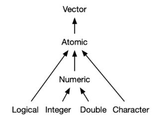

## Type of Atomic vectors

1. **Logical** (or Boolean): `TRUE`, `FALSE`, `NA`

```r
logical_test <- 3 > 5
print(logical_test)
```

```
[1] FALSE
```

```r
typeof(logical_test)
```

```
[1] "logical"
```

2. **Integer**: integer numbers

Attach `L` to treat the number as strict integer number.

```r
my_integer <- 3L # L specifies the number is integer
typeof(my_integer)
```

```
[1] "integer"
```

3. **Double**: real numbers

```r
my_number <- 3.125 # A length of 1 vector
typeof(my_number)
```

```
[1] "double"
```

**Caution**

**numeric** is a collective term for both double and integers but often used as if it were **a synonym for “double” or “real number”** in practice.

4. **Character** (or string): words, wrapped by `"` or `'`

```r
my_name <- "Matthew Son" # wrap double quotes around
korean_name <- 'Gunsu Son' # or single quotes
typeof(my_name)
```

```
[1] "character"
```

```r
typeof(korean_name)
```

```
[1] "character"
```

**Tip**

Style guide: **Use double quote** `"` for character instead of `'` if possible.

5. Two other types:
- **raw type**: binary data type
- **complex type**: complex numbers (e.g. 3 + 4i)
- rarely needed in Finance

## Missing values: NA

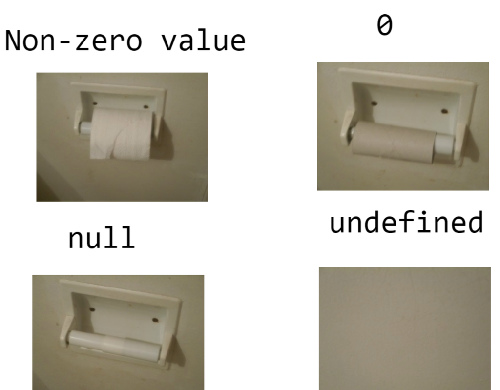

- Missing values are denoted by `NA`
  - Not Applicable: similar to “undefined” above
- They are not identical to zero or NULL
  - `NULL` is intentional empty “placeholder” in R

`NA` is considered as logical length 1 vector.

```r
typeof(NA) # "logical"
length(NA) # 1
```

`NULL` is a special type (NULL), length 0

```r
typeof(NULL) # "NULL"
length(NULL) # 0
```

`NaN` a **numeric missing value**, length 1.

- unrepresentable numeric results (e.g., 0/0, log(-1)).

```r
typeof(NaN) # "double"
length(NaN) # 1
```

## Exercise

1. What are four primary types of atomic vector?
2. What are the types of `a,b,c,d` below?

```r
a <- TRUE
b <- 3.56
c <- "Logical"
d <- 6
```

Confirm your answer with `typeof()`.

## List

List is a **generic vector** that is not atomic.

- Atomic vector can have **only one type** for its elements (Double, Integer, Logical, …)
- List can hold multiple data types for its member (even list itself)

```r
example_list <- list(1L, 3.5, 'Hi', TRUE)
print(example_list)
```

```
[[1]]
[1] 1

[[2]]
[1] 3.5

[[3]]
[1] "Hi"

[[4]]
[1] TRUE
```

```r
typeof(example_list)
```

```
[1] "list"
```

List can have atomic vectors as its elements, with varying lengths:

```r
# List construction example
# Use "=" inside function
my_list <- list(
  first_element = c(1L, 2L, 3L), # integer type, length of 3
  second_element = c('how', 'what', 'why', 'where'), # character type, length 4
  third_element = c(3 < 5, 3 == 5, 3 > 5) #logical type, length 3
)
typeof(my_list)
```

```
[1] "list"
```

**Question**: What is the length of `my_list`?

# R Object Attributes

## Attributes

Attributes are **metadata** that is attached to R objects so that it provides more information.

Common attributes:

- **Names**: Labels for elements in a vector or list
- **Dimensions (`dim`)**: Used for matrices, arrays
- **Class**: Defines **how** an object should be treated **by functions**
- etc.

## Names attribute

Elements of vector (atomic, generic) can be named.

```r
stock_prices <- c(150, 200, 250, 300)
attributes(stock_prices) # No attributes
```

To assign *names* attribute:

## Method 1: names()

```r
names(stock_prices) <- c("AAPL", "GOOG", "MSFT", "AMZN")
attributes(stock_prices) # stock_prices now have "names" attribute
```

```
$names
[1] "AAPL" "GOOG" "MSFT" "AMZN"
```

```r
print(stock_prices)
```

```
AAPL GOOG MSFT AMZN
 150  200  250  300
```

## Method 2: attr()

Or use `attr()` function to set attribute:

```r
# method 3
stock_prices <- c(150, 200, 250, 300)
attr(stock_prices, "names") <- c("AAPL", "GOOG", "MSFT", "AMZN")
attributes(stock_prices)
```

```
$names
[1] "AAPL" "GOOG" "MSFT" "AMZN"
```

## Method 3

Or assign names by construct:

```r
# method 2
stock_prices2 <- c(
  "AAPL" = 150,
  "GOOG" = 200,
  "MSFT" = 250,
  "AMZN" = 300
)
attributes(stock_prices2)
```

```
$names
[1] "AAPL" "GOOG" "MSFT" "AMZN"
```

## Exercise

```r
stock_prices <- c(100, 150)
```

Give `names` attribute to `stock_prices` vector using aforementioned three methods.

- `names(obj) <-`
- `attr(obj, "names") <-`
- by construct

## Dim attribute

Adding a dim attribute to a vector allows it to behave like a **2-dimensional matrix** or a **multi-dimensional array**.

```r
# matrix
x <- 1:6
dim(x) <- c(2, 3) # assign 2 by 3 dimension attribute
print(x)
```

```
     [,1] [,2] [,3]
[1,]    1    3    5
[2,]    2    4    6
```

```r
# array
y <- 1:8
dim(y) <- c(2, 2, 2) # 2 by 2 by 2
print(y)
```

```
, , 1

     [,1] [,2]
[1,]    1    3
[2,]    2    4

, , 2

     [,1] [,2]
[1,]    5    7
[2,]    6    8
```

## Class attribute

The **class** attributes in R is used to define the **behavior of objects** with functions.

Especially important classes in Finance are:

- Date, Time
- Factors
- Dataframe
- or your own custom-built class

## Example 1: Date/Time

Very important class in Finance.

They are built from **double type atomic vector** (type), but has own **specific rule for uses** (class).

```r
today <- Sys.Date() # returns today's date
now <- Sys.time() # returns time now
print(today)
```

```
[1] "2025-04-21"
```

```r
print(now)
```

```
[1] "2025-04-21 14:21:30 EDT"
```

Check their data type:

```r
typeof(today)
```

```
[1] "double"
```

```r
typeof(now)
```

```
[1] "double"
```

Check their attributes: they have *class* attributes.

```r
attributes(today)
```

```
$class
[1] "Date"
```

```r
attributes(now)
```

```
$class
[1] "POSIXct" "POSIXt"
```

To directly access the class attribute:

```r
class(today)
```

```
[1] "Date"
```

```r
class(now)
```

```
[1] "POSIXct" "POSIXt"
```

### Class attribute and change of behavior

For an example, see how it works with `+` function.

```r
print(today + 1) # adds one day
```

```
[1] "2025-04-22"
```

```r
print(now + 1) # adds one seconds
```

```
[1] "2025-04-21 14:21:31 EDT"
```

**Q**: Why +1 yield different results?

**A**: Because they are in **different classes**. +1 is inferred differently.

Class attribute gives some *context* how it should behave with functions.

In the deep down, they are just numbers:

```r
# strip off class attribute (only)
unclass(today)
```

```
[1] 20199
```

```r
unclass(now)
```

```
[1] 1745259691
```

- Date: The value of double represents the number of days since “1970-01-01” (Unix Epoch)
- Time: the number of seconds since Unix Epoch

### Time zone attribute

Time has “tzone” attribute (time-zone) that controls “formatting” of date-time.

- The lower-level data (double) for the time is not changing.

```r
now <- Sys.time()
print(now) # EDT time zone
```

```
[1] "2025-04-21 14:21:30 EDT"
```

```r
unclass(now) # a double number
```

```
[1] 1745259691
```

```r
# set attribute tzone to UTC
attr(now, "tzone") <- "UTC"
print(now) # formatted for UTC zone
```

```
[1] "2025-04-21 18:21:30 UTC"
```

```r
unclass(now) # same underlying number
```

```
[1] 1745259691
attr(,"tzone")
[1] "UTC"
```

## Example 2: Factors

Factors (or Categorical) can only have a set of predefined values.

- It is built on top of integer type

```r
# Factors can be ordered
firm_size <- factor(
  c("Large", "Mid", "Small"),
  levels = c("Small", "Mid", "Large"), # predetermined values
  ordered = TRUE # give increasing order to above level
)
typeof(firm_size)
```

```
[1] "integer"
```

```r
class(firm_size)
```

```
[1] "ordered" "factor"
```

```r
# Factors are unordered by default
political_parties <- factor(
  c("Democratic", "Republican")
) # unordered
typeof(political_parties)
```

```
[1] "integer"
```

```r
class(political_parties)
```

```
[1] "factor"
```

If they were stripped off all attributes:

```r
attributes(firm_size) <- NULL # remove all attributes
firm_size # integer (it gave greater number for higher level)
```

```
[1] 3 2 1
```

## Base types and Class

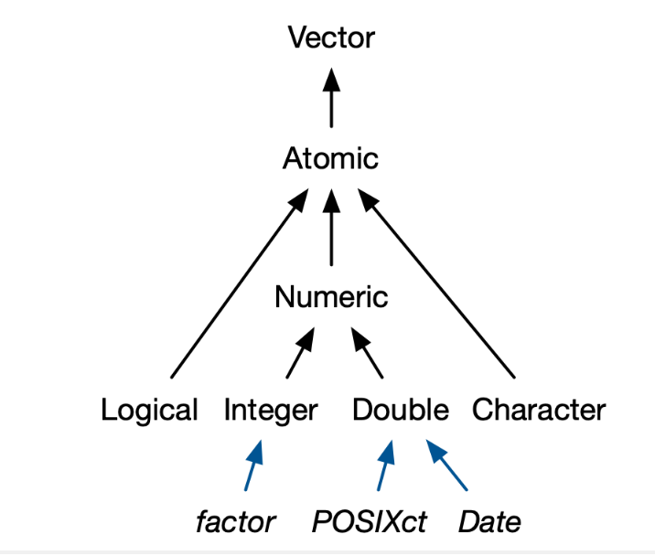

## Example 3: Dataframe & tibble

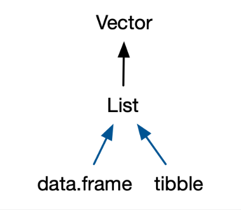

A class built on top of `list` type, with 2D tabular representations

- Similar to matrix (2D form)
- Dataframe and tibble can have different types of columns

```r
# iris is available dataframe
head(iris) # prints first 6 rows
```

```
  Sepal.Length Sepal.Width Petal.Length Petal.Width Species
1          5.1         3.5          1.4         0.2  setosa
2          4.9         3.0          1.4         0.2  setosa
3          4.7         3.2          1.3         0.2  setosa
4          4.6         3.1          1.5         0.2  setosa
5          5.0         3.6          1.4         0.2  setosa
6          5.4         3.9          1.7         0.4  setosa
```

```r
typeof(iris) # list type
```

```
[1] "list"
```

```r
class(iris)
```

```
[1] "data.frame"
```

If class attribute was removed: it turns back to list

```r
# Try !
iris_list <- unclass(iris)
print(iris_list)
```

Let’s browse the attributes of `iris` dataframe:

```r
# names (column names), class, row.names
attributes(head(iris))
```

```
$names
[1] "Sepal.Length" "Sepal.Width"  "Petal.Length" "Petal.Width"  "Species"

$row.names
[1] 1 2 3 4 5 6

$class
[1] "data.frame"
```

Tibble is a robust dataframe class.

- It has better printing output than data.frame
- Convert class with `as_tibble()`

```r
iris_tb <- as_tibble(iris)
iris_tb |> head(3)
```

```
# A tibble: 3 × 5
  Sepal.Length Sepal.Width Petal.Length Petal.Width Species
         <dbl>       <dbl>        <dbl>       <dbl> <fct>
1          5.1         3.5          1.4         0.2 setosa
2          4.9         3            1.4         0.2 setosa
3          4.7         3.2          1.3         0.2 setosa
```

```r
iris_tb |> typeof()
```

```
[1] "list"
```

## Implicit Class

Some R building-block objects have *implicit* class:

- Atomic vectors: (primary data types - Logical, Integer, Double, Character)
- Generic vector (list)
- Matrix / Array
- etc.

Their class is not shown in the `attributes()`, but still shown when explicitly asked with `class()`

```r
a <- TRUE
typeof(a)
class(a)
attributes(a) # no class attribute printed

b <- 3L
typeof(b)
class(b)
attributes(b)

c <- 3.5
typeof(c)
class(c) # double type are implicit class "numeric"
attributes(c)

d <- "A"
typeof(d)
class(d)
attributes(d)
```

## Exercise

1. Execute `typeof(c(1,2,3))` and `typeof(c(1L, 2L, 3L))`. What’s the difference?
2. Assign a vector with three elements: 1,3,5, and name it as `my_first_object`
3. Assign another object with one element: 5, name it as `MySecondObject`
4. Multiply `my_first_object` with `MySecondObject`. What do you get?
5. Assign a vector with your name: `my_name`
6. What do you get when you execute `my_name + 3`? (Expect error)

## Importance of class

Since class determines the behavior of the object, it is crucial to know your data class especially performing function calls.

**Note**

Calling a function means executing/applying a function.

As you cannot use add function on `character` and `numeric`.

```r
# Another way to perform plus
`+`(3, 4) # good
```

```
[1] 7
```

```r
`+`(3, "Hi") # error
```

```
Error in 3 + "Hi": non-numeric argument to binary operator
```

**Other example**: `c()`

**Some** functions **coerces** the class / type instead.

```r
my_vector <- c(1, 3, 'hello', 5) # Does it work?
typeof(my_vector)
```

```
[1] "character"
```

```r
class(my_vector) # it works by coercion
```

```
[1] "character"
```

**Tip**

`c()` does coercion when inputs are in different types, but not all functions do coercion.

## Exercise: coercion

Let’s see how coercion works with `c()`.

```r
test <- c(3.14, Sys.Date(), Sys.time())
```

What is the type of `test`?

What is the class of `test`?

## Coercion precedence

In general, coercion is performed in fixed order:

**Character (heavy) << Double << Integer << Logical (light)**

```r
typeof(c(TRUE))
```

```
[1] "logical"
```

```r
typeof(c(TRUE, 2L))
```

```
[1] "integer"
```

```r
typeof(c(TRUE, 2L, 3.14))
```

```
[1] "double"
```

```r
typeof(c(TRUE, 2L, 3.14, "A"))
```

```
[1] "character"
```

## Quick Check

What would be the type of:

```r
typeof(c(TRUE, 3.55))
typeof(c(3L, 5.3))
typeof(c(3L, "2.15"))
typeof(c(TRUE, 3L, 3.34, "2.15"))
typeof(c(TRUE, "FALSE"))
```

## Data type and memory footprint

Given the same length, logical and integer takes least amount of memory, then double, then character

```r
lobstr::obj_size(c(TRUE, FALSE, TRUE)) # uses integer for memory footprint internally
```

```
64 B
```

```r
lobstr::obj_size(c(3L, 15L, -5L))
```

```
64 B
```

```r
lobstr::obj_size(c(3.12, 53.1, 6.22))
```

```
80 B
```

```r
lobstr::obj_size(c("A", "B", "C"))
```

```
248 B
```

# R Access Operations

## Vector Indexing

- Single square brackets `[` and `]`
  - Subset multiple elements from vector
- Double brackets `[[` and `]]`
  - Subset **single** element (scalar) from vector

## Vector indexing: Single brackets

Square brackets `[` selects multiple elements of vector

- by index: x[1] retrieves first element
- by name: x[“Bob”] retrives element named “Bob”

```r
prices <- c(AAPL = 150, MSFT = 205, GOOGL = 250, AMZN = 303)

# Access by name attributes

prices[["AAPL"]] # single (double bracket)
```

```
[1] 150
```

```r
prices[c("MSFT", "GOOGL")] # multiple (single bracket)
```

```
 MSFT GOOGL
  205   250
```

Elements can be accessed with index:

- Positive integer: select
- Negative integer: exclude

```r
# Access by index
prices[1] # first element
prices[c(1, 3)] # 1st and 3rd element
prices[-c(1, 4)] # excluding first and fourth element
```

- You can’t mix positive and negative index

```r
prices[c(-1, 5)]
```

```
Error in prices[c(-1, 5)]: only 0's may be mixed with negative subscripts
```

## Vector indexing: Double brackets

Use double brackets `[[` on vector when you want to select **single element** (Scalar).

**Tip**

Style guide: while single bracket still works, use `[[` on vectors to *reinforce* your expectation.

```r
# single value from an atomic vector
prices[1] # Ok (keeps names)
```

```
AAPL
 150
```

```r
prices[[1]] # Better
```

```
[1] 150
```

## Subset & Assignment on Vector

Subsetting vector can be combined with assignment `<-` to modify selected values.

```r
print(prices)
```

```
 AAPL  MSFT GOOGL  AMZN
  150   205   250   303
```

```r
prices[[1]] <- 235 # use double bracket for single element selection
print(prices)
```

```
 AAPL  MSFT GOOGL  AMZN
  235   205   250   303
```

```r
prices[["AMZN"]] <- 295
print(prices)
```

```
 AAPL  MSFT GOOGL  AMZN
  235   205   250   295
```

Assigning multiple elements:

```r
# Use single bracket for multiple elements
prices[c(2,4)] <- 265
print(prices)
```

```
 AAPL  MSFT GOOGL  AMZN
  235   265   250   265
```

## Exercise

1. Generate stock price vector:

```r
stock_prices <- c("MSFT" = 200, "TSLA" = 255, "AAPL" = 230, "GOOG" = 215)
```

2. Access 1st and 3rd element of `stock_prices`
3. Assign “MSFT” and “AAPL” to 300.

You can subset vector with logical vector inside brackets:

```r
prices[prices > 230] # subset price greater than 200
```

```
 AAPL  MSFT GOOGL  AMZN
  235   265   250   265
```

```r
(prices %% 2) == 0 # a logical vector : TRUE if even number
```

```
 AAPL  MSFT GOOGL  AMZN
FALSE FALSE  TRUE FALSE
```

```r
is_even <- (prices %% 2) == 0
prices[is_even] # subset of x that is even number
```

```
GOOGL
  250
```

```r
prices[(prices %% 2) == 0] # is the same as above
```

```
GOOGL
  250
```

## Exercise

Generate below stock prices:

```r
stock_prices <- c(TSLA = 680, FB = 355, NFLX = 540, NVDA = 800, AAPL = 145)
```

Subset and get the following:

- Stocks whose prices greater than $250
- Subset stocks whose prices that are even
- Modify prices greater than $600 to $360

## 2. List Indexing

There are 3 ways to index lists that each has own merits:

- Single square brackets `[` `]` : returns original (list) type
- Double square brackets `[[` `]]` : returns element’s type
- Dollor sign operator `$`

A list is like a train carring multiple cars:

```r
x <- list(1:3, "a", 4:6)
```

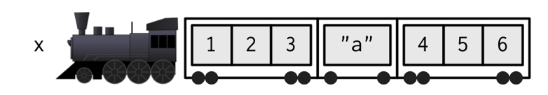

## List Indexing: Single brackets

Single bracket returns a list object, train.

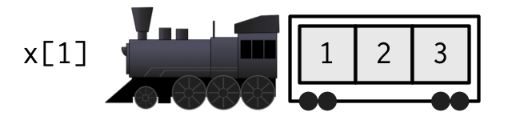

```r
x[1]
```

```
[[1]]
[1] 1 2 3
```

## List Indexing: Double brackets

Double bracket returns element’s type, car.

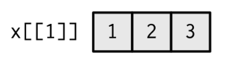

```r
x[[1]]
```

```
[1] 1 2 3
```

## List Indexing: `$` Operator

`$` is a shorthand operator for double bracket `[[` with a variable name.

- Access variable without quotes (`"`)
- Autocompletion friendly

```r
# They are (roughly) equivalent
x[["var1"]]
x$var1
```

## Portfolio example

Construct a list of portfolio:

```r
portfolio <- list(
  stocks = c(AAPL = 150, TSLA = 680),
  bonds = c(TBOND = 1000),
  cash = 5000,
  brokerage = 'Robinhood'
)
```

Subset by number index:

```r
portfolio[[1]] # double bracket: returns vector (element type)
portfolio[1] # single bracket: returns list
```

Subset by name:

```r
portfolio[["bonds"]] # double bracket: returns vector
portfolio["bonds"] # single bracket: returns list

portfolio$bonds # dollar sign: returns vector
```

## Assignment on Lists

You can use chained bracket operation and assignment:

```r
portfolio[["stocks"]][["TSLA"]] <- 630 # replacement
portfolio[["bonds"]][["TBOND5Y"]] <- 210 # new value
print(portfolio)
```

```
$stocks
AAPL TSLA
 150  630

$bonds
  TBOND TBOND5Y
   1000     210

$cash
[1] 5000

$brokerage
[1] "Robinhood"
```

You can remove a component of list by assigning `NULL`

```r
portfolio[["brokerage"]] <- NULL
print(portfolio)
```

```
$stocks
AAPL TSLA
 150  630

$bonds
  TBOND TBOND5Y
   1000     210

$cash
[1] 5000
```

## Element removal on atomic vectors

Assigning NULL to an element of a vector doesn’t work:

```r
prices <- c(100, 200, 300)
prices[[1]] <- NULL # Doesn't work
```

```
Error in prices[[1]] <- NULL: replacement has length zero
```

Should use negative indexing & overwrite in this case:

```r
prices <- prices[-1] # except for first element
print(prices)
```

```
[1] 200 300
```

## Exercise

Create a list object `portfolio` as:

```r
portfolio <- list(
  stocks = c(AAPL = 150, TSLA = 680),
  bonds = c(TBOND = 1000),
  cash = 5000,
  brokerage = 'Robinhood'
)
```

Subset the portfolio to:

1. Retrieve the stocks vector using index
2. Retrieve the cash vector using its name
3. Return a list of stocks and cash using their names
4. Return a list containing only bonds
5. Remove brokerage element from portfolio

# R Functions

## Functions

> Everything that **exists** is an object.  
> Everything that **happens** is a function call.

> — *John Chambers*

## Function calls

Fuction calls in R come in four varieties.

1. **prefix**: function name comes **before** its arguments

```r
# Prefix example
function_name(argument1 = value1, argument2 = value2, ...) function_body
```

2. **infix**: function name comes in **between** arguments

```r
# Infix example
x + y
```

3. **replacement**: function that **replaces value** by assignments

```r
# Replacement example
names(stock_prices) <- c("AAPL", "BAC", "CA")
```

4. **special**: Built-in R syntax like `[[` `for` `if`, and don’t have consistent structure.

```r
# Special example
stock_prices[[1]]
```

## Rewriting to prefix form

An intersting property of R is that every inflix, replacement, and special form can be rewritten in **prefix** form.

- use backtick `` ` `` to wrap the function symbol

```r
1:5 # infix call
`:`(1, 5) # prefix call

x <- c(1, 2)
names(x) <- c("A", "B") # replacement call
x <- `names<-`(x, c("C", "D")) # prefix call

x[[1]] # special call
`[[`(x, 1) # prefix call
```

Our first *prefix* function call, `c()` concatenates all the values and generate a single object.

- `c()` has arbitrary number of arguments (`...`)

```r
# c() function takes arbitrary number of arguments (... part)
c(1, 3, 5)
c(1, 3, 5, 7, 9)
```

`seq()` function generates a sequence of numbers.

- It has three arguments: `from` and `to` and `by`.

```r
# generate a vector of sequence from 1 to 10 by 2
seq(from = 1, to = 10, by = 2)
```

```
[1] 1 3 5 7 9
```

- If users don’t specify the argument name, it reads input in order.

```r
seq(1, 10, 2) # reads first three
```

```
[1] 1 3 5 7 9
```

- If user enters more args than the function space, raises error.

```r
seq(1, 10, 2, 5)
```

```
Error in seq.default(1, 10, 2, 5): too many arguments
```

Some functions has pre-defined argument value:

```r
# max(..., na.rm = FALSE)
max(c(1,2,3,NA)) # NA
max(c(1,2,3,NA), na.rm = TRUE) # 3
```

## Defining a function

You can define custom function (User-defined function) in R with the following syntax:

```r
# simple form
function_name <- function(x, y) function_body

# full form
function_name <- function(arg1, arg2) {
  # write what the function would to with arguments
  return() # output
}
```

The function can be called in prefix form:

```r
function_name(argument1 = 1, argument2 = "hi")
```

Default argument value can be assigned by construction:

```r
my_first_function <- function(argument1 = NULL, argument2 = "hi", arg3) {

  print(argument2)

}
```

**Q:** What would happen if user calls above function with

- `my_first_function()`

## Curly Braces

By default, R evaluates **each line** as in individual statement.

```r
square_function <- function(x) x^2
```

Using curly braces { } allows you to group multiple expressions into a single unit that executes together.

```r
some_other_function <- function(x) {
  squared <- x^2
  result <- squared + 10
  return(result)
}
```

## Exercise

Prep: Load `stringr` package with `library(stringr)`

1. Write your own function `say_hello()` that takes no argument. It prints “Hi!” when called.
2. Now tweak the function to accept an argument, `name`. It prints “Hello, {name}!”
- Use `str_glue("Hello, {name}!")`

## Returning Values in Functions

`return()` in function can be served as an early exit: all remaining code won’t be executed.

```r
my_second_function <- function(a, b = 1) {

  c <- a + b
  return(c)

  print(a)
}
my_second_function(a = 1, b = 2)
```

```
[1] 3
```

## Function Fundamentals

A function has three parts:

1. The `formals()`: list of arguments
2. The `body()`: code inside the function
3. The `environment()`: where you defined the function
   - “GlobalEnv” : top-level workspace in the R session

```r
some_function <- function(x, y = 1) {
  i <- 1
  ans <- x + y + i
  return(ans)
}
```

Check `formals()`, `body()` and `environment()`:

```r
# formals: list of arguments
formals(some_function) # Is i included? check.
# body: code inside of function
body(some_function)
# environment: where is the function object located
environment(some_function)
```

Some functions are found from external packages:

```r
environment(stringr::str_glue) # glue function from stringr package
```

## Getting Help on Functions

All R functions are built by someone, and documentation is typically provided.

For detailed description of any function, use `?` followed by the function’s name.

For example, try below code in your console:

```r
?seq
```

Or, use `help()`

```r
help(seq)
```

## Build a Perpetuity Calculator

where

- PMT is the payment or cash flow.
- r is the discount rate.
- g is the growth rate of the cash flow.

This formula applies when r > g.

## Defining a function

You can design your perpetuity function in R with following syntax:

```r
pv_per <- function(pmt, r, g) {
  # write what the function would to with arguments
  n <- pmt
  d <- r - g

  # then return the result
  return(n / d)
}
```

## Calling a function

Let’s call the function above:

- What is the PV of perpetuity, when PMT = $10,000, r = 7% and g = 3%?

```r
pv_per(pmt = 10000, r = 0.07, g = 0.03)
```

```
[1] 250000
```

- Assign the result value of the function

```r
answer <- pv_per(10000, 0.07, 0.03)
print(answer)
```

```
[1] 250000
```

- Vector can be the input (vectorized)

```r
pv_per(c(100, 1000, 10000), 0.07, 0.03) # r, g recycled
```

```
[1]   2500  25000 250000
```

```r
pv_per(c(100, 1000, 10000), c(0.07, 0.05, 0.04), 0.03) # g recycled
```

```
[1]    2500   50000 1000000
```

## Exercise

1. Define a perpetuity calculator function, `pv_per()`. What is the pv when PMT = $50,000, r = 4%, g = 0%?
2. What is the pv when PMT = $50,000, r = 4%, but g are 1%, 2%, 3%?

## Default Arguments

What happens if user doesn’t specify one argument?

```r
pv_per(10000, 0.07) # g is missing!
```

```
Error in pv_per(10000, 0.07): argument "g" is missing, with no default
```

You can set default values for arguments, allowing them to be omitted when calling the function.

```r
# set default g to be zero
pv_per2 <- function(pmt, r, g = 0) {
  n <- pmt
  d <- r - g
  # then return the result
  return(n / d)
}
# prefix call without g specified
pv_per2(10000, 0.07)
```

```
[1] 142857.1
```

## Example 2: Black-Scholes Pricing

Functions can do more complex calculations. Following the Black-Scholes put / call pricing formula, we can generate function as below:

```r
bsm_price <- function(S0, K, r, T, sigma, type = "call") {
  d1 <- (log(S0 / K) + (r + 0.5 * sigma^2) * T) / (sigma * sqrt(T))
  d2 <- d1 - sigma * sqrt(T)

  if (type == "call") {
    return(S0 * pnorm(d1) - K * exp(-r * T) * pnorm(d2))
  } else if (type == "put") {
    return(K * exp(-r * T) * pnorm(-d2) - S0 * pnorm(-d1))
  } else {
    stop("Invalid option type. Use 'call' or 'put'.")
  }
}
```

Calculate price estimates with four scenarios:

```r
S0 <- c(100, 105, 110, 115)   # Stock prices
K <- c(100, 100, 100, 100)    # Strike prices
r <- 0.05                # Risk-free rate
T <- c(1, 0.5, 2, 0.05)        # Time to maturity
sigma <- c(0.2, 0.25, 0.3, 0.4) # Volatility

bsm_price(S0, K, r, T, sigma) # vectorized operation!
```

```
[1] 10.45058 11.47739 28.31895 15.47719
```

## Anonymous function

```r
# Anonymous function example
function(x, y) {
  return(x + y + 1)
}
```

Functions are typically **named** so they can be reused multiple times.

However, you can skip naming a custom function, and they are called *anonymous function*.

- Useful when the function is simple and called only one time.

They are not stored as objects since they do not have assigned symbols (names).

## Syntactic sugar: Function

**Note**

**Syntactic sugar** refers to a feature in programming that **makes the code simple to read or write**, without adding functionality.

(Anonymous) functions can be defined with syntactic sugar (concise expression):

```r
\(x, y) x + y + 1

\(x, y) {
  x + y + 1
} # or with curly braces
```

## Exercise

Convert below perpetuity function (`pv_per`) to anonymous function:

```r
pv_per <- function(pmt, r, g) {
  return(pmt / (r - g))
}
```

## Syntactic sugar: Pipe Operator

*A Motivating example*

Solve below math problem. Describe your steps. What was the first and the last step?

$$\sqrt{(2+4)^2 - 3 * 4} = ?$$

$$\sqrt{(2+4)^2 - 3 * 4}$$

1. Do 2+4 `and then` square it, and save it in your memory
2. Do 3*4 `and then` subtract it from previous, and update your memory
3. `and then` square root the value
- Similarly, codes can be written **not** in the order we calculate.
- It is easier for us to read & write code in the order it is operated.

When we have composite function calls such as

```r
f(g(h(k(x))))
```

The call sequence is `x -> k() -> h() -> g() -> f()`.

It is rather easier to read, write and debug if we can write a code like:

```r
# Note: this is not a real code!
x then
  call k() on above and then
  call h() on above output and then
  call g() on above output and then
  call f() on above output
```

## Pipe operator & Function Chain

This is where pipe operator `|>` becomes handy in R.

The pipe operator does **“and then”** job, and it can be written as:

```r
x |>
  k() |>
  h() |>
  g() |>
  f() # Do not put pipe at the end!
```

**Tip**

Style guide: use `|>` instead of `%>%`. Use shortcut `Cmd (Ctrl) + Shift + M`.

Sometimes you’ll see `%>%` operator instead, which comes from external library in R (magrittr), meanwhile `|>` is R native. In order to use `%>%`, external package `library(magrittr)` should be imported.

## Exercise (challenge!)

Solve $\sqrt{2^3}$ using pipe operator.

1. First, solve above procedual way
- For square root, use `sqrt()` function
2. Next, solve using the pipe operator.
- Define function named `cube` that does `x^3`
- Code should start with `2`.

## External packages

**Packages** are add-on libraries that extend the functionality of R.

- They provide additional **functions**, datasets, and tools for various tasks
- Can be easily installed with `install.packages()`
- And loaded in R session with `library()`

Installing packages:

```r
# Installs tidyverse package if not installed
# Once installed, you don't need to install again
if (!requireNamespace("tidyverse", quietly = TRUE)) {
  install.packages("tidyverse")
}
```

Load packages: you need to load packages to use its functionality.

- Need to load only once per session

```r
library(tidyverse)
```

# Control Structure

## Control Structure?

Control structure dictates **which** code gets executed and **when**.

1. Conditional Statements:
   - **`if` statements**: Execute code if a condition is true.
   - **`else`/`else if` statements**: Execute code if the condition is false.
2. Loops:
   - **`for` loops**: Repeat code block a specified number of times.
   - **`while` loops**: Continue executing code as long as a condition is true.
3. Map (apply):
   - Map a **function** to each element of a collection *without explicitly writing loops*.

## If-else

The basic form of `if` and `if-else` statement in R:

```r
# Simple form
if (condition) true_action
if (condition) true_action else false_action

# Full form
if (condition) {
  true_action
} else {
  false_action
}
```

```r
# Simple form
x1 <- if (TRUE) 1 else 2
# Full form
x2 <- if (FALSE) {
  1
} else {
  2
}
print(c(x1, x2))
```

```
[1] 1 2
```

Example 1: *if* and *else* executes code based on logical conditions.

```r
stock_price <- 115
if (stock_price > 110) {
  print("The stock price has increased significantly!")
}
```

```
[1] "The stock price has increased significantly!"
```

Example 2: If condition is not met, then nothing happens (skipped).

```r
stock_price <- 100
if (stock_price > 105) {
  print("The stock price has increased!")
}
```

Example 3: *else if* checks one more logic condition:

```r
stock_price <- 115
if (stock_price > 120) {
  print("The stock price has surged!")
} else if (stock_price > 110) {
  print("The stock price has increased moderately.")
}
```

```
[1] "The stock price has increased moderately."
```

Example 4: There can be multiple *else if*

```r
stock_price <- 108
if (stock_price > 120) {
  print("The stock price has surged!")
} else if (stock_price > 110) {
  print("The stock price has increased moderately.")
} else if (stock_price > 105) {
  print("The stock price has increased slightly.")
}
```

```
[1] "The stock price has increased slightly."
```

Example 5: *else* is executed when all of if conditions are not met.

```r
stock_price <- 100
if (stock_price > 120) {
  print("The stock price has surged!")
} else if (stock_price > 110) {
  print("The stock price has increased moderately.")
} else if (stock_price > 100) {
  print("The stock price has increased slightly.")
} else {
  print("The stock price has decreased.")
}
```

```
[1] "The stock price has decreased."
```

## Exercise

Write an if-else statement:

- If PMT > 1000, add PMT with 10000 (i.e., `PMT <- PMT + 10000`)
- Else if PMT > 500, add PMT with 100
- Else, set PMT = 0

What is the outcome of above if-else, if initial PMT was 750?

## For loops

For loops are used when code has to be *iterated* a specified number of times.

```r
# Syntax
for (item in vector) {
  action
}
```

```r
for (i in 1:5) {
  print(i)
}
```

```
[1] 1
[1] 2
[1] 3
[1] 4
[1] 5
```

If `for` loop was explictly written:

```r
# loop variable i
i <- 1
print(i)
```

```
[1] 1
```

```r
i <- 2
print(i)
```

```
[1] 2
```

```r
i <- 3
print(i)
```

```
[1] 3
```

```r
i <- 4
print(i)
```

```
[1] 4
```

```r
i <- 5
print(i)
```

```
[1] 5
```

`for` assigns the `item` in the current environment, overwriting existing variable with the same name.

```r
i <- 100 # i exists before loop

for (i in 1:3) {}

print(i) # for loop overwrites
```

```
[1] 3
```

Items are accessed one by one in vector in for loop:

```r
tickers <- c("AAPL", "BAC", "C", "DAL")
for (t in tickers) {
  print(t)
}
```

```
[1] "AAPL"
[1] "BAC"
[1] "C"
[1] "DAL"
```

To use index for each element: use `seq_along()` on the vector.

```r
tickers <- c("AAPL", "BAC", "C", "DAL")
seq_along(tickers) # converts to integer sequence
```

```
[1] 1 2 3 4
```

```r
for (num in seq_along(tickers)) {
  print(num)
}
```

```
[1] 1
[1] 2
[1] 3
[1] 4
```

When looping over date / times, loops strip the attributes:

```r
dates <- as.Date(c("2020-01-01", "2020-05-01"))
for (dat in dates) {
  print(dat)
}
```

```
[1] 18262
[1] 18383
```

To workaround, use indexing with `seq_along()` and `[[`.

```r
dates <- as.Date(c("2020-01-01", "2020-05-01"))
for (i in seq_along(dates)){
  print(dates[[i]])
}
```

```
[1] "2020-01-01"
[1] "2020-05-01"
```

## For loop: preallocation

When generating an output, make sure to **preallocate** output container.

- Generate empty output container with specified **type** and **length**
- Combining scheme with `c()` is **strongly discouraged**

```r
# Think about the type and length of output before loop
N <- 10
output <- vector(mode = "list", length = N) # empty output container

for (n in 1:N) {
  output[[n]] <- n**2 # same as n^2
}
print(output)
```

```
[[1]]
[1] 1

[[2]]
[1] 4

[[3]]
[1] 9

[[4]]
[1] 16

[[5]]
[1] 25

[[6]]
[1] 36

[[7]]
[1] 49

[[8]]
[1] 64

[[9]]
[1] 81

[[10]]
[1] 100
```

## Benchmark Example

```r
N <- 5000
appending <- vector("list")
no_prealloc <- vector("list") # or use list() for empty list
prealloc <- vector("list", length = N)

bench::mark(
  appending_method = for (n in 1:N) {
    appending <- c(appending, n**2)
  },
  no_prealloc_method = for (n in 1:N) {
    no_prealloc[[n]] <- n**2
  },
  prealloc_method = for (n in 1:N) {
    prealloc[[n]] <- n**2
  },
  iterations = 2,
  check = FALSE
)
```

```
# A tibble: 3 × 6
  expression              min   median `itr/sec` mem_alloc `gc/sec`
  <bch:expr>         <bch:tm> <bch:tm>     <dbl> <bch:byt>    <dbl>
1 appending_method      231ms 298.36ms      3.35    95.6MB     28.5
2 no_prealloc_method    931µs   1.16ms    860.     830.1KB      0
3 prealloc_method         1ms   1.01ms    988.      54.8KB      0
```

## next and break

Generally used with if-else condition tests inside loop.

`next` is used to skip an iteration of loop.

```r
for (i in 1:5) {
  if (i == 3) {
    # skip if i == 3
    next
  }
  print(i)
}
```

```
[1] 1
[1] 2
[1] 4
[1] 5
```

`break` is used to exit loop immediately.

```r
for (i in 1:5) {
  if (i == 4) {
    break
  }
  print(i)
}
```

```
[1] 1
[1] 2
[1] 3
```

## For loop: Compound interest

How to calculate compound interest over multiple years using a `for` loop?

- Principal: $10,000
- Interest rate: 5%
- Number of years: 10

```r
principal <- 10000
rate <- 0.05
num_periods <- 10
# generate placeholder vector for the cashflow
cashflow <- vector("numeric", length = num_periods)

for (i in 1:num_periods) {
  value <- principal * (1 + rate)^i
  cashflow[[i]] <- value
}
print(cashflow)
```

```
 [1] 10500.00 11025.00 11576.25 12155.06 12762.82 13400.96 14071.00 14774.55
 [9] 15513.28 16288.95
```

## Exercise

Based on the previous example, do the following:

- Q1. Skip the first year using if and next
  - Cashflow should have zero (NULL) on the first slot
- Q2. Stop the calculation if value exceeds $14,000
  - Cashflow should have zero (NULL) on slots that exceed value of $14,000

## While loops

While loops begin with testing condition, and iterates the code **as long as** the condition is `TRUE`.

- If not written properly, it can be infinite loop.

```r
count <- 0
while (count < 3) {
  print(count)
  count <- count + 1 # add 1
}
```

```
[1] 0
[1] 1
[1] 2
```

## Exercise

1. Write code that print 1 to 10 using for loop.
2. Achieve same result using while loop instead.
   - Start by defining `a <- 1` outside of the loop
3. Based on 2, tweak the code that skips printing number if it is 5.
   - Be careful not get into infinite loop!

## Exercise 2

Write a **function** that checks class of an input.

If the input is `numeric`, print “Numeric input!”, otherwise, print “Not numeric!”

- use `inherits(x, "numeric")` for logical test.

```r
# example outcome
my_function(c(1, 4, 5))
```

```
[1] "Numeric input!"
```

```r
my_function(c('a', 'b', 'c'))
```

```
[1] "Not numeric!"
```

## Function mapping

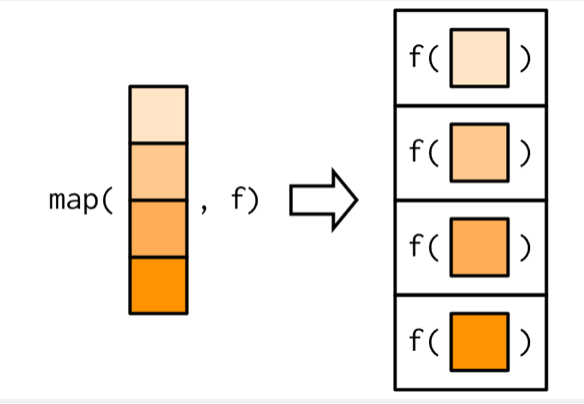

*map* function from `purrr` is an implicit function loop.

- a function `f` is an input arg for `map()`
- Succinct and easy to read than `for` loops
- `map()` requires `tidyverse` or `purrr` package

**Note**

Functions that take other function as inputs are called **functionals** in R, like `map()`.

Remember, though, if vectorized operation is possible, avoid using for loops or map.

## Example: `map()`

- Output is **always list**

```r
plus_one <- function(x) {
  return(x + 1)
}
# need to import tidyverse to use map()
# library(tidyverse)
map(1:3, plus_one) # 1 2 3 is input for plus_one()
```

```
[[1]]
[1] 2

[[2]]
[1] 3

[[3]]
[1] 4
```

With for loop, code tends to be longer and requires preallocation.

```r
# define empty list for output first
temp_list <- vector("list", length = 3)

for (i in 1:3) {
  # assign each to the list
  temp_list[[i]] <- plus_one(i)
}
print(temp_list)
```

```
[[1]]
[1] 2

[[2]]
[1] 3

[[3]]
[1] 4
```

## Exercise

1. Generate `times_two()` function that multiplies input by 2.
2. map `times_two` function over `1:10`
3. Achieve same result with for loop.

## map function 2

If the desired *output* is not list but atomic vector:

- **`map_dbl()`** a numeric (double) vector
- **`map_chr()`** a character vector
- **`map_lgl()`** a logical vector
- **`map_int()`** an integer vector

```r
map(1:3, plus_one) |> class()
```

```
[1] "list"
```

```r
map_dbl(1:3, plus_one) |> class()
```

```
[1] "numeric"
```

## Vectorized Operation and Loops

Most function operations in R are vectorized by default.

- Intuitive and faster: easier to read, write
- R is built for those operations in mind
- **Avoid** using `for` loops or `map` **if vectorization is possible**

**Example: portfolio value**

```r
stock_prices <- c(150, 250, 100)
shares_held <- c(10, 5, 20)
# multiplication is vectorized
portfolio_value = stock_prices * shares_held
print(portfolio_value) # easy and faster
```

```
[1] 1500 1250 2000
```

A `for` loop approach:

```r
N <- length(stock_prices) # length 3
portfolio_value <- vector("numeric", N) # container

for (i in 1:N) {
  portfolio_value[[i]] <- stock_prices[[i]] * shares_held[[i]]
}
print(portfolio_value)
```

```
[1] 1500 1250 2000
```

A `map` approach:

- map `*` function to two input vectors (price, share)
- `map2()` for this case, see `?map2` for more info

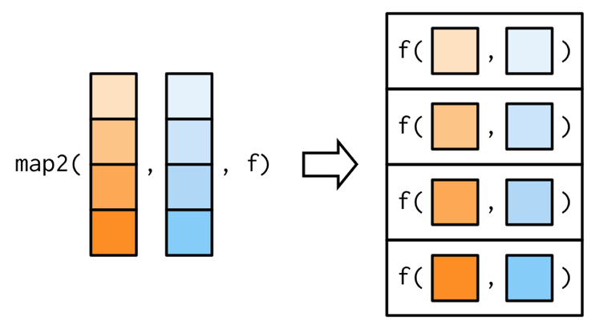

```r
portfolio_value <- map2(stock_prices, shares_held, `*`)
print(portfolio_value)
```

```
[[1]]
[1] 1500

[[2]]
[1] 1250

[[3]]
[1] 2000
```

## Benchmark comparison

```r
bench::mark(
  vectorizing = {portfolio_value <- stock_prices * shares_held},
  map2 = {portfolio_value <- map2(stock_prices, shares_held, `*`)},
  for_loop_prealloc = {
    portfolio_value <- vector("numeric", N) # container
    for (i in 1:N) {
      portfolio_value[[i]] <- stock_prices[[i]] * shares_held[[i]]
    }},
  iterations = 100,
  check = FALSE
)
```

```
# A tibble: 3 × 6
  expression             min   median `itr/sec` mem_alloc `gc/sec`
  <bch:expr>        <bch:tm> <bch:tm>     <dbl> <bch:byt>    <dbl>
1 vectorizing           82ns     82ns  8901477.        0B      0
2 map2                48.2µs   51.2µs    19052.      264B      0
3 for_loop_prealloc  865.9µs  954.7µs     1018.    20.1KB     20.8
```

## Exercise

```r
stock_prices <- c(150, 250, 100, 250, 300)
shares_held <- c(10, 5, 20, 5, 10)
```

Generate portfolio value of each asset, using:

1. Vectorized multiplication (vector output)
2. for loop
3. map (implicit loop)

## Vectorized if-else

`ifelse()` function is a vectorized if else statement.

- Useful when you have *a vector* of TRUE / FASE condition tests
- No need to loop over each element of vector

```r
ifelse(test, yes, no)
```

**Example: Dividend Payments**

```r
stock_prices <- c(45, 60, 52, 48, 55, 49)

dividends <- ifelse(
  stock_prices > 50, # test
  stock_prices * 0.02, # yes
  stock_prices * 0.015 # no
)

print(dividends)
```

```
[1] 0.675 1.200 1.040 0.720 1.100 0.735
```

## Exercise

```r
stock_prices <- c(45, 60, 52, 48, 55, 49)
```

Practice `ifelse()`:

- if stock price is greater than 53, assign “Bull”
- otherwise “Bear”
- assign it to `sentiment` object.

## Vectorized if-else 2

`case_when()` from `tidyverse` package is a **general** vectorized if-else.

```r
library(tidyverse)
stock_prices <- c(45, 60, 52, 48, 55, 49)

sentiment2 <- case_when(
  stock_prices > 55 ~ "Bull", # if TRUE
  stock_prices > 53 ~ "Normal", # else if TRUE
  stock_prices > 49 ~ "Weak", # else if TRUE
  .default = "Bear" # else
)
print(sentiment2)
```

```
[1] "Bear"   "Bull"   "Weak"   "Bear"   "Normal" "Bear"
```

## Exercise 2

```r
stock_prices <- c(45, 60, 52, 48, 55, 49)
```

Practice `case_when()`:

- if stock price is greater than 58, assign “Bull”
- if stock price is greater than 50, assign “Normal”
- otherwise “Bear”
- assign it to `sentiment2` object.

# File Systems in R

## Package fs

`fs` package provides simple and consistent way to:

- Path operations
- File and directory control
- File information
- **Cross-platform**

```r
# Install package
if (!requireNamespace("fs", quietly = TRUE)) {
  install.packages("fs")
}
```

## What is a Path?

A **path** is a string of characters used to uniquely identify a file or folder in a file system.

Types of paths:

- **Absolute path**: exact location of a file or directory from the root.
- **Relative path**: location relative to the current working directory.

## Working Directory

The working directory is the location **where the program (R, bash, Python, etc) is running on**.

- `getwd()` shows the current working directory.
- `setwd("/path/to/directory")` changes working directory to specified path.

## Absolute Paths

- Begins from the root directory (`/` in Mac/Linux, `C:\` in Windows)
- Example (Mac/Linux): `/Users/username/Documents/project/data.csv`
- Example (Windows): `C:\Users\username\Documents\project\data.csv`

Absoulte paths are unambiguous.

## Relative Paths

- Path that is relative to the current working directory.
- Example: `./data/project/data.csv` (The `.` denotes the current directory)
- Succinct and easier to manage path in projects

## Directory references

**`.`**: the current directory.

- From `/Users/john/projects`, `./data` refers to `/Users/john/projects/data`.

**`..`**: the parent directory; one level up from the current directory.

- From `/Users/john/projects`, `../data` refers to `/Users/john/data`.

**`~`**: the home directory.

- Default directory for user in OS

## Home Directory

The “default” directory for user in operating system

**Mac/Linux**: `/Users/<username>`. - Example: If your username is `john`, your home directory would be `/Users/john`.

**Windows**: `C:\Users\<username>` - Example: If your username is `john`, your home directory would be `C:\Users\john`

## Tilde `~`

Represents the user’s home directory.

Example: `~/cases` refers to the cases folder in the user’s home directory:

- `C:\Users\<username>\cases` for windows
- `/Users/john/cases` for Mac/Linux

## Creating File/Directory

Creatie / delete file and directory are simple:

```r
# Create file and folder in the working directory
library(fs)
file_create("my_Rscript.R")
dir_create("my_folder")
```

```r
file_delete("my_Rscript.R")
dir_delete("my_folder")
```

## List files and directories

List files and directories:

```r
dir_ls(".") # list files in current directory
```

It’s especially useful with globbing / regex:

```r
dir_ls(glob = "*.txt") # list txt files
```

## Exercise

1. Create an R script file named: `fs_exercise.R` on your working directory.

```r
# Check your working directory with
getwd()
```

2. List all files that has `.R` file extension.
3. What is the absolute path of the script file?
4. From your home(`~`), what is the relative path of the script file?

## Text Data Files

A plain, human-readable text data file, delimited by a specific character

- Comma-Separated Values (CSV) with `,`
- Tab-Separated Values (TSV) with `\t`
- Since it is text, R tries to “guess” the correct data type of each column when importing

## Text Data Example

A text data file typically looks like:

- Usually the first line is a header (column names)
- Data values separated by a delimiter (e.g., `,` for CSV, `\t` for TSV)

```
Sepal.Length,Sepal.Width,Petal.Length,Petal.Width,Species
5.1,3.5,1.4,0.2,setosa
4.9,3,1.4,0.2,setosa
4.7,3.2,1.3,0.2,setosa
```

```r
# TSV
iris |> head(3) |> format_tsv() |> cat()
```

```
Sepal.Length    Sepal.Width Petal.Length    Petal.Width Species
5.1 3.5 1.4 0.2 setosa
4.9 3   1.4 0.2 setosa
4.7 3.2 1.3 0.2 setosa
```

## Text Data files

Many packages support writing/reading csv/tsv files;

- base R (`utils` package): basic, slow
- `readr` from `tidyverse`: extremely fast, functional

## Write CSV / TSV

To write a `data.frame` to a csv file: `write_csv()`

```r
# Saves csv / tsv file on current working directory
write_csv(iris, "iris_file.csv")
write_tsv(iris, "iris_file.tsv")
```

To read a `.csv` / `.tsv` file to a data.frame: `read_csv()`, `read_tsv()`

```r
my_iris <- read_csv('iris_file.csv')
my_iris2 <- read_tsv("iris_file.tsv")
```

## Other data formats

There are other common data formats:

- “.xlsx”: excel spread sheets
- “.json”: javascript object notation (NoSQL)
- “.parquet”: columnar big data storage
- ‘.sas7bdat’, ‘.dta’

# R Data frame (and tibble) class

## Data frames

One of the most important data class in R, built on top of list type.

- Stores data structure in 2D tabular form:
  - with rows (observations, or records)
  - and columns (variables)
- Columns can be different types!

## Create data frame

Creating a data.frame is almost identical to list.

```r
# creating data.frame is similar to creating a list
my_dataframe <- data.frame(
  a = c(1, 2, 3),
  b = c('a', 'b', 'c'),
  c = c(TRUE, FALSE, FALSE)
)
print(my_dataframe)
```

```
  a b     c
1 1 a  TRUE
2 2 b FALSE
3 3 c FALSE
```

## Exercise

Create a dataframe named as `housing`:

- 6 columns: Name, Age, Sex, Income, Housing, Zipcode
  - Name: Amy, Bill, Charles, Donna, Eckert
  - Age: 21, 25, 30, 38, 49
  - Sex: Female, Male, Male, Female, Male
  - Income: 36000, 53000, 89000, 82000, 166000
  - Housing: Rent, Rent, Own, Own, Rent
  - Zipcode: 12333, 12543, 11255, 12333, 33533

What are the type (class) of each column automatically recognized by R?

- Check with `str(housing)`.

**Q**: What should be their type (class) in theory?

## Tibble class

**Essentially the same** as dataframe class, with some fix:

- Fixes *old inconsistencies* in R data.frame class
- Safer executions
- Better console displays

`as_tibble()` converts `data.frame` class to `tibble` class.

## Example

A toy dataset, `iris` dataframe:

```r
head(iris, 3)
```

```
  Sepal.Length Sepal.Width Petal.Length Petal.Width Species
1          5.1         3.5          1.4         0.2  setosa
2          4.9         3.0          1.4         0.2  setosa
3          4.7         3.2          1.3         0.2  setosa
```

Class of iris:

```r
class(iris)
```

```
[1] "data.frame"
```

Convert `iris` to *tibble* class:

- Prints the dimension
- Prints data class by column

```r
iris_tb <- as_tibble(iris)
head(iris_tb, 3)
```

```
# A tibble: 3 × 5
  Sepal.Length Sepal.Width Petal.Length Petal.Width Species
         <dbl>       <dbl>        <dbl>       <dbl> <fct>
1          5.1         3.5          1.4         0.2 setosa
2          4.9         3            1.4         0.2 setosa
3          4.7         3.2          1.3         0.2 setosa
```

`iris_tb` is a multi-class object that is both tibble and dataframe.

```r
class(iris_tb)
```

```
[1] "tbl_df"     "tbl"        "data.frame"
```

## Access operations

As it is built on lists, `[`, `[[`, `$` also works on data.frames.

- bracket operations align more consistently with `tibble` class

Dataframe can be subsetted with `df[i,j]`

- `i` part operates on row (called filtering)
- `j` part selects columns

## Bracket `[`, `[[` subsetting

```r
iris_tb[, 1] # vector? tibble?
iris_tb[1, 1] # vector? tibble?
iris_tb[1,] # vector? tibble?
```

1st row, 1st column, in element class (numeric vector)

```r
iris_tb[[1, 1]]
```

```
[1] 5.1
```

**Caution**

Double bracket `[[` works with `,` only when both row and columns are mentioned. That is, `iris_tb[[1,1]]` works, but `iris_tb[[,1]]` doesn’t.

To `pull` in element’s (vector) class, you’ll learn `pull()`.

Other examples:

```r
# Exercise: try!
iris_tb[, c("Sepal.Length", "Petal.Width")]
iris_tb[1:5, 1:2]
iris_tb[iris_tb[["Sepal.Length"]] > 3.1, 1] # filtering
```

If comma is not provided, it **assumes a column index**.

```r
# try and see the difference!
iris_tb[1]
iris_tb["Sepal.Length"]
iris_tb[["Sepal.Length"]]
```

**`$` subsetting**

`$` pulls a single column in element’s class from data frame (tibble).

```r
iris_tb$Sepal.Length
```

## Exercise

1. Generate `iris_tb` by converting `iris` using `as_tibble()`.
2. Exercise all subsetting methods on rows in the 2nd column:
- Use single bracket and integer index `iris_tb[2]`
- Use double bracket and integer index `iris_tb[[2]]`
- Use single bracket and column name `iris_tb[colname]`
- Use single bracket and column name `iris_tb[[colname]]`
- Use `$`
3. Filter rows with “Sepal.Length > 5”. How many rows do you observe?
- use `nrow()` to check the number of rows.

## Chained subset call

Subsetting can be chained

- Pause and take a look at example. What is happening?

```r
iris_tb[21:100, c('Petal.Length', 'Sepal.Length')][25, ]
```

- Confirm with `iris_tb[45, c("Petal.Length", "Sepal.Length")]`

## Exercise

On `iris_tb`,

- Filter with “Petal.Length > 4.5”
- Select columns “Species”, “Petal.Length”
- then slice rows from 1 to 10
- Store this as `filtered_iris`

**Q**. Confirm the average of Petal.Length from `filtered_iris` is **4.74**.

- Use `mean(dataframe$column)`.

## Assign and remove column

They operate as same as lists. To assign a new variable within the data.frame, use:

```r
data.frame["NEW_COLUMN_NAME"] <- NEW_COLUMN
data.frame[["NEW_COLUMN_NAME"]] <- NEW_COLUMN # same

# EXAMPLE
iris_tb["Petal.Area"] <- iris$Petal.Length * iris$Petal.Width
```

To remove a variable from the data.frame, use:

```r
data.frame["EXISTING_NAME"] <- NULL
data.frame[["EXISTING_NAME"]] <- NULL
```

## Modern syntax: dplyr package

[figure not shown]

R package for **dataframe** manipulation tasks.

- A **grammar** of data manipulation
- Replaces the use of `[`, `[[`, `$` in most cases
- Intuitive and easy to understand
- Fast, written in C++

## Prep: Company Financials Data

`Company_financials.csv` data will be available in our GitHub Class repository.

- Option 1: Git pull and copy the data to your class working folder

```r
install.packages("fs")
# Adjust the address to your setting
fs::file_copy(
  "Class_repo/FIN4470_Spring2025/Data/Company_Financials.csv", # from
  "Company_Financials.csv" # to
  )
```

- Option 2: Direct address typing as below

```r
library(tidyverse)
url <- "https://raw.githubusercontent.com/matthewgson/FIN4770_Spring2025/refs/heads/main/Data/Company_financials.csv"
fin_data <- read_csv(url)
```

## Data Overview

- Balance Sheet items: Assets, Liabilities, Equity, etc
- Year: reporting year
- Industry: Industry classification for each company
- Company: Ticker symbol

## The `select()` verb

`select()` lets you choose specific columns.

- by column names
- by index
- by helper functions (starts_with, ends_with, etc)

```r
fin_data |>
  select(ticker, Industry)  # column names
fin_data |>
  select(1:5) # index
```

Suppose you want to select all current items that starts with “current”.

```r
fin_data |>
  select(ticker, Industry, year, starts_with("current"))
```

or ends with “libabilities”.

```r
fin_data |>
  select(ticker, Industry, year, ends_with("liabilities"))
```

or contains “asset”

```r
fin_data |>
  select(ticker, Industry, year, contains("asset"))
```

## The `relocate()` verb

`relocate()` is used to change the order of columns.

```r
fin_data |>
  relocate(market_cap) # move to left-most

fin_data |>
  relocate(market_cap, .before = market_cap) # move before market_cap

fin_data |>
  relocate(market_cap, .after = last_col()) # move to far-right
```

## The `rename()` verb

`rename()` changes the column names.

```r
fin_data |>
  rename(
    Ticker = ticker, # left is new name
    Year = year
  )
```

## The `pull()` verb

`pull()` extracts a single column as a vector.

```r
fin_data |>
  pull(ticker) # vector

fin_data |>
  select(ticker) # tibble
```

## Exercise

Using the dataset `fin_data`:

1. Create new tibble that includes only “ticker”, “Industry”, “year”, “market_cap” and column that starts with “current”.
2. Relocate column “market_cap” as the first column.
3. Rename “market_cap” to “Market_Cap” column.
4. Pull “ticker” as a vector from `fin_data`.
5. Combine 1 to 4 with pipe chain to achieve all at once.

## The `filter()` verb

`filter()` lets you choose rows based on conditions.

```r
# Single filter
fin_data |>
  filter(year >= 2022)

# Multiple filter
fin_data |>
  filter(
    year >= 2022,
    Industry == "Financials"
  )

fin_data |>
  filter(
    between(market_cap, 1e11, 1e12), # between 100B to 1T
    Industry %in% c("Financials", "Energy")
  )
```

Apply filters across columns: `if_any()` and `if_all()`

> Imagine your dataset includes multiple asset columns (e.g., current assets and current liabilities). You want to filter rows where any asset value exceeds $100B (1e11).

```r
fin_data |> \
  filter(
    if_any(
      c(current_assets, current_liabilities), \(x) x > 1e11))
```

`if_all()` for strict filtering:

```r
fin_data |>
  filter(
    if_all(
      c(current_assets, current_liabilities), \(x) x > 1e11))
```

## The `slice()` verb

`slice()` extrats rows based on simple positions.

```r
fin_data |>
  slice(1:5)

fin_data |>
  slice(-(1:10)) # drop

fin_data |>
  slice_sample(n = 10) # random

fin_data |>
  slice_max(current_assets, n = 3) # top 3 values
```

## The `disctinct()` verb

`distinct()` removes duplicate rows based on referred columns.

```r
fin_data |>
  distinct(Industry) # distinct values of Industry

fin_data |>
  distinct(Industry, .keep_all = TRUE) # keeps other columns
```

## Exercise

From `fin_data`:

1. Filter that contains only rows where year is greater than 2022 and Industry is “Financials”.
2. Filter rows where any of columns that contains “asset” exceeds $100B (1e11).
3. Filter rows where all of columns that contains “current” exceed $10B (1e10).
4. Slice first 3 rows of the data.
5. Show distinct values of “Industry” in the data, and keep other columns.

## The `arrange()` verb

`arrange()` reorders the rows by one or more columns.

```r
fin_data |>
  arrange(current_assets) # ascending by default

fin_data |>
  arrange(desc(current_assets)) # descending

fin_data |>
  arrange(ticker, year, current_assets) # hierachical ordering
```

**Caution**

Best practice: DO NOT CHAIN ARRANGE - it resets reordering.

```r
# Wrong
fin_data |>
  arrange(ticker) |>
  arrange(current_assets)

# Correct
fin_data |>
  arrange(ticker, current_assets)
```

## The `mutate()` verb

`mutate()` lets you create or modify columns.

```r
fin_data |>
  mutate(
    debt_asset_ratio = current_debt / current_assets,
    equity = total_assets - total_debt
  )
```

Using general if-else with `case_when()` to classify:

```r
fin_data |>
  mutate(
    debt_asset_ratio = current_debt / current_assets,
    Leverage_category = case_when(
      debt_asset_ratio >= 0.8 ~ "High Leverage",
      debt_asset_ratio >= 0.5 ~ "Moderate Leverage",
      TRUE ~ "Low Leverage")
      )
```

## Exercise

From `fin_data`:

1. Arrange the data by ticker (ascending) and year.
2. Create new variable “debt_to_asset_ratio” as the ratio of current_debt to current_assets.

## The `summarize()` verb

`summarize()` computes statistics for the entire dataset.

```r
fin_data |>
  summarize(
    avg_current_assets = mean(current_assets, na.rm = TRUE),
    max_assets = max(current_assets, na.rm = TRUE)
  )
```

You can summarize by groups:

```r
fin_data |>
  group_by(ticker) |>
  summarize(
    avg_current_assets = mean(current_assets, na.rm = TRUE)
  ) |>
  ungroup() # manual ungroup needed
```

Or simply use `.by` in the `summarize()`

```r
fin_data |>
  summarize(
    avg_current_assets = mean(current_assets, na.rm = TRUE),
    .by = ticker
  ) # ungroupped after summary
```

## Lab Problem: Year-over-Year Growth Calculation

From `fin_data`:

1. Arrange the dataset by ticker and year in ascending order. Then, group the data by ticker.
2. Use mutate() along with the lag() function to calculate the year-over-year growth rate for current_assets. Name the variable as `yearly_asset_growth`.

$\frac{\mathrm{current_assets} - \mathrm{lag(current_assets)}}{\mathrm{lag(current_assets)}}$

3. Summarize the average of yearly growth rate by each tickers.

## dplyr grammar summary

**Key verbs**

1. `select()` : select subset of columns
- `rename()` : rename columns
- `relocate()` : change column positions
- `pull()` : extract single column as vector
2. `filter()` : select subset of rows with condition
- `slice()` : extract specific rows
- `distinct()` : remove duplicate rows
3. `arrange()` : reorder rows
4. `mutate()` : add new columns (variables)
5. `summarize()` : generate summary table
- `group_by()` / `ungroup()`

# Portfolio Sorting with Crypto

A mini finance project

## Incorporating AI for Coding

From now on, I’ll introduce how to leverage AI for coding.

- Generating code snippets
- Troubleshoot and debug
- Best Practices

## Sample GenAIs for code

1. ChatGPT
2. Grok
3. Claude.ai (limited)
4. Meta.ai
5. Gemini

## Crypto Analysis with `dplyr` and `tidyverse`

Learn to:

- Financial data manipulation
- Calculate average returns and volatility
- Sort cryptocurrencies into portfolios
- Compare performance of different portfolios
- **Visualize** performance

Let’s optimize our crypto investments!

## Prep Required Libraries

```r
# Install yourself before loading
library(tidyquant)
library(tidyverse)
```

Our list of cryptos: 9 sample

```r
crypto_coins <- c("BTC-USD", "ETH-USD", "BNB-USD",
                  "SOL-USD", "XRP-USD", "DOT-USD",
                  "DOGE-USD", "MATIC-USD", "ADA-USD")
```

## Get data

```r
# Get historical prices for the selected coins
crypto_data <- tq_get(crypto_coins,
                      from = "2020-01-01",
                      to = "2023-01-01") # 3 years
```

How many observations are found for each crpto?

```r
# Not all of coins have same number of observations
crypto_data |>
  summarize(n(), .by = symbol)
```

```
# A tibble: 9 × 2
  symbol    `n()`
  <chr>     <int>
1 BTC-USD    1097
2 ETH-USD    1097
3 BNB-USD    1097
4 SOL-USD     997
5 XRP-USD    1097
6 DOT-USD     865
7 DOGE-USD   1097
8 MATIC-USD  1097
9 ADA-USD    1097
```

## Calculate Returns

Calculate daily returns with `arrange()`, `group_by()` and `mutate()`

```r
crypto_data <- crypto_data |>
  arrange(symbol, date) |>
  group_by(symbol) |>
  mutate(daily_ret = adjusted / lag(adjusted) - 1) |> # arithmetic return
  ungroup()

crypto_data |> head()
```

```
# A tibble: 6 × 9
  symbol  date         open   high    low  close   volume adjusted daily_ret
  <chr>   <date>      <dbl>  <dbl>  <dbl>  <dbl>    <dbl>    <dbl>     <dbl>
1 ADA-USD 2020-01-01 0.0328 0.0338 0.0327 0.0335 22948374   0.0335  NA
2 ADA-USD 2020-01-02 0.0335 0.0335 0.0324 0.0328 20843934   0.0328  -0.0211
3 ADA-USD 2020-01-03 0.0327 0.0344 0.0325 0.0342 30162644   0.0342   0.0436
4 ADA-USD 2020-01-04 0.0342 0.0347 0.0339 0.0346 29535781   0.0346   0.0121
5 ADA-USD 2020-01-05 0.0346 0.0354 0.0345 0.0347 21479178   0.0347   0.00364
6 ADA-USD 2020-01-06 0.0348 0.0373 0.0347 0.0373 37988444   0.0373   0.0735
```

## Performance metrics

Calculate performance metrics with `group_by()` and `summarize()`

```r
performance_metrics <- crypto_data |>
  group_by(symbol) |>
  summarize(
    avg_daily_ret = mean(daily_ret, na.rm = TRUE),
    vol_daily = sd(daily_ret, na.rm = TRUE)
  )
performance_metrics
```

```
# A tibble: 9 × 3
  symbol    avg_daily_ret vol_daily
  <chr>             <dbl>     <dbl>
1 ADA-USD         0.00356    0.0588
2 BNB-USD         0.00421    0.0570
3 BTC-USD         0.00150    0.0379
4 DOGE-USD        0.00807    0.135
5 DOT-USD         0.00270    0.0678
6 ETH-USD         0.00333    0.0505
7 MATIC-USD       0.00668    0.0805
8 SOL-USD         0.00548    0.0793
9 XRP-USD         0.00247    0.0634
```

## Visualize metrics

Visualize performance metrics with `ggplot()`, to generate barplot:

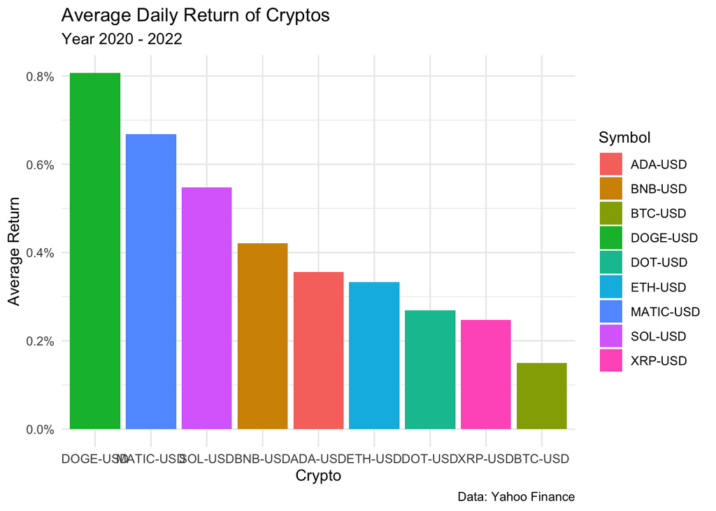

```r
performance_metrics |>
  ggplot(
    aes(x = fct_reorder(symbol, -avg_daily_ret), y = avg_daily_ret, fill = symbol )
  ) +
  geom_col() +
  scale_y_continuous(labels = scales::percent_format())+
  labs(
    title = "Average Daily Return of Cryptos",
    subtitle = "Year 2020 - 2022",
    caption = "Data: Yahoo Finance",
    x = "Crypto",
    y = "Average Return",
    fill = "Symbol"
  ) +
  theme_minimal()
```

Similarly for volatility:

[figure not shown]

```r
performance_metrics |>
  ggplot(
    aes(x = fct_reorder(symbol, vol_daily), y = vol_daily, fill = symbol )
  ) +
  geom_col() +
  scale_y_continuous(labels = scales::percent_format())+
  labs(
    title = "Average Daily Return of Cryptos",
    subtitle = "Year 2020 - 2022",
    caption = "Data: Yahoo Finance",
    x = "Crypto",
    y = "Average Return",
    fill = "Symbol"
  ) +
  theme_minimal()
```

To combine and juxtapose (simple):

- Can’t use double Y axis with this case
- Reorder factor before pivotting if needed

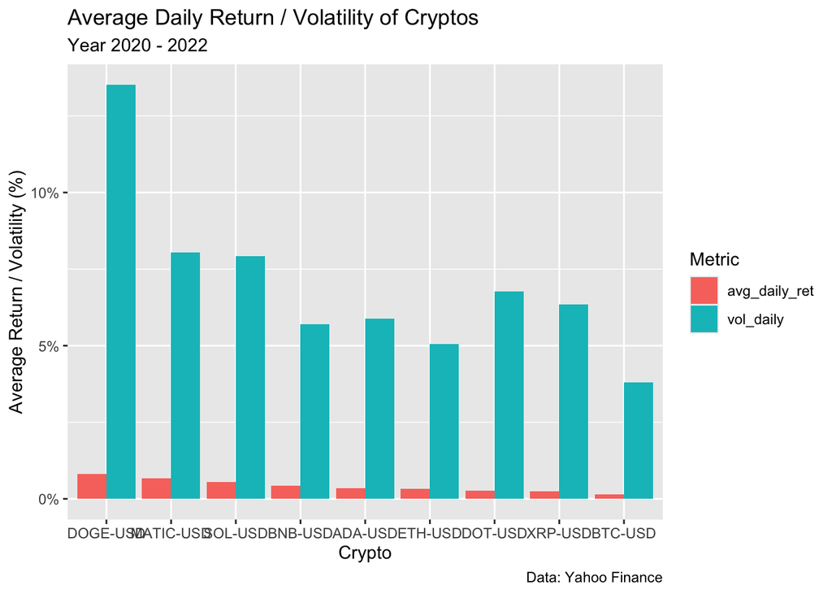

```r
performance_metrics |>
  mutate(symbol = fct_reorder(symbol, desc(avg_daily_ret))) |>
  pivot_longer(cols = !symbol) |>  # make long form
  ggplot(
    aes(x = symbol, y = value, fill = name)
  ) +
  geom_col(position = "dodge") +
  scale_y_continuous(labels = scales::percent_format()) +
  labs(
    title = "Average Daily Return / Volatility of Cryptos",
    subtitle = "Year 2020 - 2022",
    caption = "Data: Yahoo Finance",
    x = "Crypto",
    y = "Average Return / Volatility (%)",
    fill = "Metric"
  )
```

To combine and juxtapose (advanced):

- Dual Y Axis technique

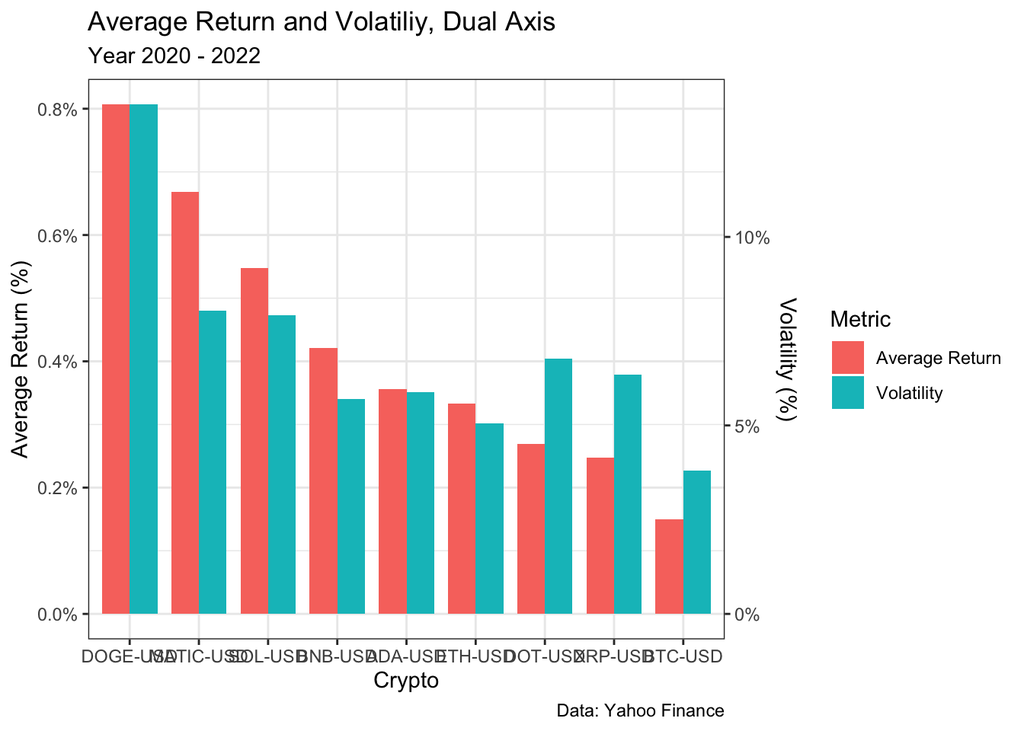

```r
# Since return is smaller: scale by their max values
scale_factor <- max(performance_metrics$avg_daily_ret) / max(performance_metrics$vol_daily)

performance_metrics |>
  ggplot(aes(x = fct_reorder(symbol, -avg_daily_ret))) +
  geom_col(
    aes(y = avg_daily_ret, fill = "Average Return"),
    position = position_nudge(x=-0.2), # move to left
    width = 0.4
  ) +
  geom_col(
    aes(y = vol_daily * scale_factor, fill = "Volatility"), # notice the scale factor
    position = position_nudge(x=0.2), # move to right
    width = 0.4) +
  scale_y_continuous(
    name = "Average Return (%)",
    labels = scales::percent_format(),
    sec.axis = sec_axis(
      \(x) x / scale_factor,
      name = "Volatility (%)",
      labels = scales::percent_format())
  ) +
  labs(
    title = "Average Return and Volatiliy, Dual Axis",
    subtitle = "Year 2020 - 2022",
    caption = "Data: Yahoo Finance",
    x = "Crypto",
    fill = "Metric"
  )  +
  theme_bw()
```

## Portfolio Sorting: Trading volume

A simple univariate portfolio sorting to see if “trading volume” predicts future returns.

1. Calculate average trading volume and sort into quintile (5) groups

```r
ranks <- crypto_data |>
  summarize(avg_daily_volume = mean(volume, na.rm = TRUE), .by = symbol)
ranks <- ranks |>
  mutate(
    volume_rank = ntile(avg_daily_volume, 5) # Ascending, Low 1 High 5
  )
head(ranks)
```

```
# A tibble: 6 × 3
  symbol   avg_daily_volume volume_rank
  <chr>               <dbl>       <int>
1 ADA-USD       1874739609.           3
2 BNB-USD       1554934937.           2
3 BTC-USD      36702325339.           5
4 DOGE-USD      1712255288.           3
5 DOT-USD       1392992622.           2
6 ETH-USD      18924519134.           4
```

Let’s test if volume explains *future* crypto returns:

- Volume observed data from 2020-01-01 to 2023-01-01
- 1 month future daily returns

```r
# Get data
future_crypto <- tq_get(crypto_coins, from = "2023-01-02", to = "2023-02-01")
future_crypto <- future_crypto |>
  arrange(symbol,date) |>
  mutate(daily_ret = adjusted / lag(adjusted) - 1, .by = symbol)
```

Join rank (from past observation) to future crypto data using “symbol” as key

```r
future_crypto <- future_crypto |>
  left_join(ranks, by = join_by(symbol)) # Now ranks are joined
head(future_crypto)
```

```
# A tibble: 6 × 11
  symbol  date        open  high   low close    volume adjusted daily_ret
  <chr>   <date>     <dbl> <dbl> <dbl> <dbl>     <dbl>    <dbl>     <dbl>
1 ADA-USD 2023-01-02 0.250 0.256 0.247 0.254 159328803    0.254  NA
2 ADA-USD 2023-01-03 0.254 0.255 0.251 0.253 153555529    0.253  -0.00407
3 ADA-USD 2023-01-04 0.253 0.270 0.252 0.268 289945179    0.268   0.0589
4 ADA-USD 2023-01-05 0.268 0.270 0.264 0.269 175511469    0.269   0.00532
5 ADA-USD 2023-01-06 0.269 0.279 0.268 0.279 326480796    0.279   0.0355
6 ADA-USD 2023-01-07 0.279 0.280 0.273 0.277 166488086    0.277  -0.00555
# ℹ 2 more variables: avg_daily_volume <dbl>, volume_rank <int>
```

Generate average crypto daily return by volume rank:

```r
portfolio_analysis <- future_crypto |>
  summarize(avg_daily_ret_by_volume_sorting = mean(daily_ret, na.rm = TRUE), .by = volume_rank)
portfolio_analysis |>
  arrange(volume_rank)
```

```
# A tibble: 5 × 2
  volume_rank avg_daily_ret_by_volume_sorting
        <int>                           <dbl>
1           1                         0.0228
2           2                         0.0109
3           3                         0.0126
4           4                         0.00829
5           5                         0.0121
```

Visualize (bar plot): basic plot

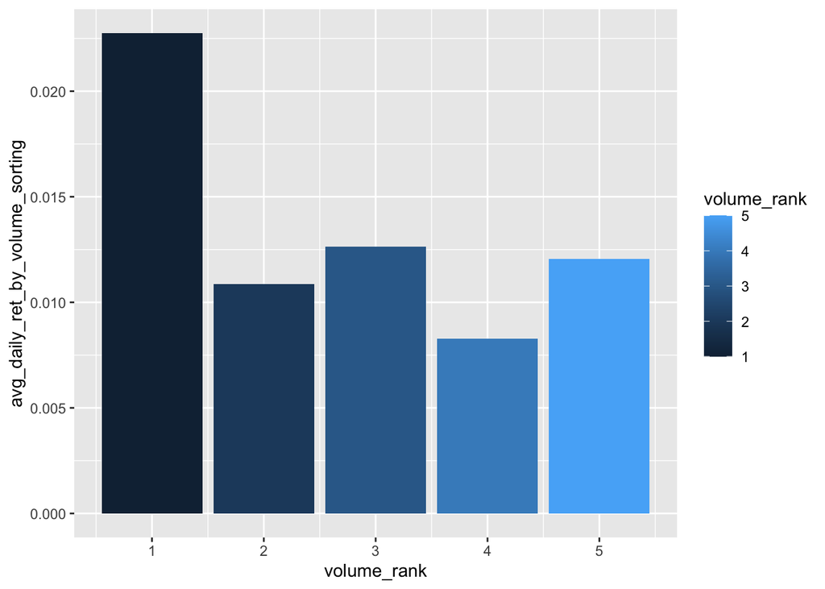

```r
portfolio_analysis |>
  ggplot(aes(x = volume_rank, y = avg_daily_ret_by_volume_sorting, fill = volume_rank)) +
  geom_col()
```

Problems:

- volume_rank is considered as numeric
- labels, themes, etc

Finalizing plot:

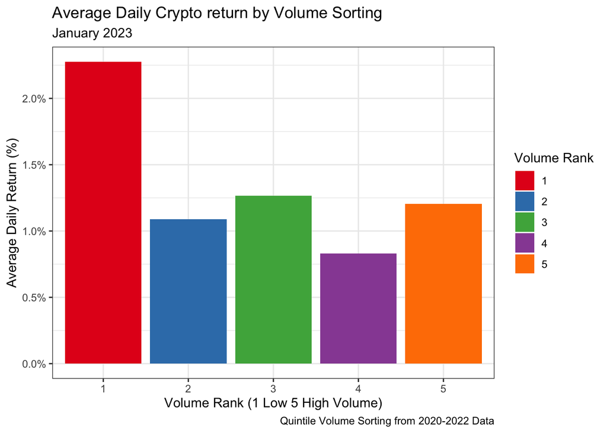

```r
portfolio_analysis |>
  mutate(volume_rank = as.factor(volume_rank)) |>
  ggplot(aes(x = volume_rank, y = avg_daily_ret_by_volume_sorting, fill = volume_rank)) +
  geom_col() +
  labs(
    title = "Average Daily Crypto return by Volume Sorting",
    subtitle = "January 2023 ",
    caption = "Quintile Volume Sorting from 2020-2022 Data",
    x = "Volume Rank (1 Low 5 High Volume)",
    y = "Average Daily Return (%)",
    fill = "Volume Rank"
  ) +
  scale_y_continuous(labels = scales::percent_format()) +
  scale_fill_brewer(palette = "Set1") +
  theme_bw()
```

**Notes**

This analysis for a demo. For a more rigor, consider:

- Expand the sample scope (8~9 cryptos may not be good enough to generalize)
- Test on different time frames

# Factor Vectors

## Factors

Factors represent categorical variables that contains a **fixed and known set of possible values**.

They’re useful when you want to display character vectors in a specific, **non-alphabetical order**.

**Note**

I introduce `forcats::fct()` instead of base R’s `factor()`, which improves its behavior.

## Why Use Factors?

Factors solve two common problems with character vectors:

1. **Typos and invalid entries**: Factors restrict inputs to predefined categories.
2. **Sorting**: Factors can sort according to a custom order, rather than alphabetically.

## Creating Factor Variables

Use the `forcats::fct()` function from the `forcats` package (part of the tidyverse):

```r
library(tidyverse)

# The valid bond ratings
rating_levels <- c("AAA", "AA", "A", "BBB", "BB", "B", "CCC")

# Create a factor of bond ratings using valid levels
ratings <- fct(c("BBB", "AA", "A", "CCC"), levels = rating_levels)
ratings
```

```
[1] BBB AA  A   CCC
Levels: AAA AA A BBB BB B CCC
```

Sorting factors respects the defined level’s sequence, as if it was an order:

```r
sort(ratings)
```

```
[1] AA  A   BBB CCC
Levels: AAA AA A BBB BB B CCC
```

If values **not in the levels** appear, `forcats::fct()` raises **an error**:

```r
ratings_invalid <- fct(c("BBB", "AA", "D", "A"), levels = rating_levels)
```

```
Error in `fct()`:
! All values of `x` must appear in `levels` or `na`
ℹ Missing level: "D"
```

```r
ratings_invalid
```

```
Error: object 'ratings_invalid' not found
```

If levels are not mentioned when defined, it honors initial input ordering:

```r
country_factor <- fct(c("USA", "Canada", "South Korea"))
levels(country_factor)
```

```
[1] "USA"         "Canada"      "South Korea"
```

**Tip**

Base R’s `factor()` doesn’t behave like this, but uses alphabetical ordering, which is discouraged behavior.

## Accessing Factor Levels

`level` is very important attribute of factor objects.

```r
attributes(ratings)
```

```
$levels
[1] "AAA" "AA"  "A"   "BBB" "BB"  "B"   "CCC"

$class
[1] "factor"
```

To modify or browse `level` attribute, use `levels()`. If levels change, corresponding values are recoded.

```r
levels(ratings)
```

```
[1] "AAA" "AA"  "A"   "BBB" "BB"  "B"   "CCC"
```

```r
levels(ratings) <- 1:7
ratings
```

```
[1] 4 2 3 7
Levels: 1 2 3 4 5 6 7
```

AAA becomes 1, AA becomes 2, and so on, preserving the order.

## Recoding Factor Levels

A convenient and safer way to recode is to use `fct_recode()`

```r
rating_levels <- c(
  "AAA", "AA", "A",
  "BBB", "BB", "B", "CCC") # possible values
bond_ratings <- fct(
  c("AAA","BBB", "A", "BB", "AA"),
  levels = rating_levels)

bond_ratings <- fct_recode(bond_ratings,
  "Top Tier" = "AAA",
  "High Grade" = "AA",
  "Medium Grade" = "A",
  "Lower Grade" = "BBB",
  "Speculative" = "BB"
)
bond_ratings # B and CCC level remains
```

```
[1] Top Tier     Lower Grade  Medium Grade Speculative  High Grade
Levels: Top Tier High Grade Medium Grade Lower Grade Speculative B CCC
```

## Collapsing Factor Levels

Use `fct_collapse()` to combine multiple levels:

```r
credit_ratings <- fct(c("AAA", "AA", "A", "BBB", "BB", "B"))

credit_ratings_collapsed <- fct_collapse(credit_ratings,
  "Investment" = c("AAA", "AA", "A"),
  "Speculative" = c("BBB", "BB", "B")
)

credit_ratings_collapsed
```

```
[1] Investment  Investment  Investment  Speculative Speculative Speculative
Levels: Investment Speculative
```

## Reorder Factor level by hand

You can reorder level by using `fct_relevel()`. Any levels not mentioned will be left in their existing order, after the explicitly mentioned levels.

```r
stock_returns <- tibble(
  Ticker = fct(c("AAPL", "MSFT", "GOOG", "JPM", "BAC")),
  Sector = fct(c("Technology", "Technology", "Technology", "Financial", "Financial")),
  Return = c(0.12, 0.08, 0.10, 0.05, 0.04)
)

stock_returns |>
  mutate(Reordered_Ticker = fct_relevel(Ticker, "GOOG")) |>
  pull(Reordered_Ticker)
```

```
[1] AAPL MSFT GOOG JPM  BAC
Levels: GOOG AAPL MSFT JPM BAC
```

## Reorder Factor level by variable

Use `fct_reorder(f,x)` to reorder factor level according to `x`. It doen’t change position of real value, but level!

```r
stock_returns |>
  mutate(Ticker_reordered = fct_reorder(Ticker, Return)) |>
  pull(Ticker_reordered)
```

```
[1] AAPL MSFT GOOG JPM  BAC
Levels: BAC JPM MSFT GOOG AAPL
```

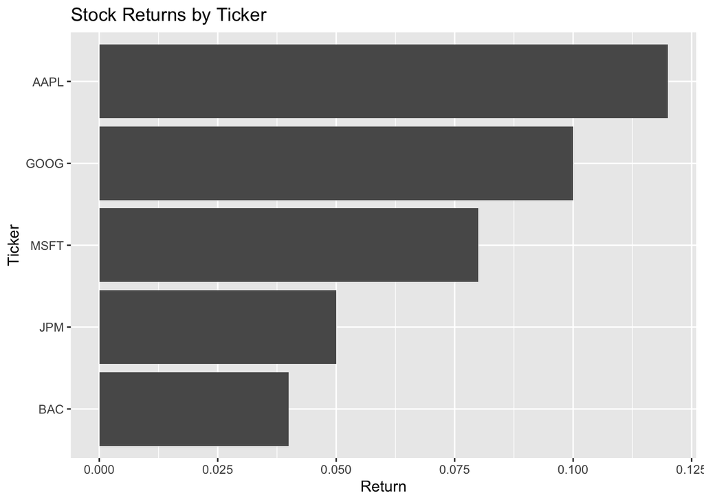

```r
stock_returns |>
  ggplot(aes(x = Return, y = fct_reorder(Ticker, Return))) +
  geom_col() +
  labs(title = "Stock Returns by Ticker", y = "Ticker", x = "Return")
```

## Lump infrequent levels

`fct_other()` lumps together infrequent levels to “other” category.

```r
ratings_full <- factor(
  c("AAA", "AA", "A", "BBB",
  "BB", "B", "CCC", "AA",
  "CCC", "B", "BBB", "D",
  "E", "A", "BBB", "BBB"))

ratings_grouped <- fct_other(ratings_full, keep = c("AAA", "AA", "A", "BBB"))
ratings_grouped
```

```
 [1] AAA   AA    A     BBB   Other Other Other AA    Other Other BBB   Other
[13] Other A     BBB   BBB
Levels: A AA AAA BBB Other
```

## Lump infrequent levels by frequency

`fct_lump()` lumps together infrequent levels to “other” category, by `n` or `prop`

```r
fct_lump(ratings_full, n = 2) # most prevalent 2
```

```
 [1] Other AA    A     BBB   Other B     CCC   AA    CCC   B     BBB   Other
[13] Other A     BBB   BBB
Levels: A AA B BBB CCC Other
```

```r
fct_lump(ratings_full, prop = 0.1) # at least 10% proportion
```

```
 [1] Other AA    A     BBB   Other B     CCC   AA    CCC   B     BBB   Other
[13] Other A     BBB   BBB
Levels: A AA B BBB CCC Other
```

## Anonymize Levels

The `fct_anon()` function replaces the existing levels with anonymous (generic) labels.

```r
ratings <- factor(c("AAA", "AA", "A", "BBB", "BB"))

# Replace factor levels with anonymous labels
anonymous_ratings <- fct_anon(ratings)
anonymous_ratings
```

```
[1] 5 2 1 3 4
Levels: 1 2 3 4 5
```

## Exercises

Create a factor market_regime from the vector `c("Bear", "Sideways", "Bull")` such that the order is Bull, Sideways, then Bear.

Then, recode the levels to “Downturn”, “Flat”, and “Upturn”

Use `fct_recode()` to change the names.

Given the following tibble of regional sales data:

```r
regional_sales <- tibble(
  region = c(
    "Northwest", "Southeast",
    "Midwest", "Northeast"),
  avg_sales = c(120, 80, 150, 100)
)
```

Reorder the region factor based on avg_sales in ascending order and create a bar plot showing average sales by region.

Use `fct_reorder(region, avg_sales)` inside `ggplot(aes())`

You have a factor investment_style with the following values:

```r
investment_style <-
  fct(
    c("Growth", "Value", "Blend",
    "Contrarian", "Speculative",
    "Growth", "Value")
    )
```

Collapse the factor into two groups using `fct_collapse()`

Traditional: includes “Growth”, “Value”, “Blend”

Alternative: includes “Contrarian”, “Speculative”

Given a vector of currency codes:

```r
currencies <- c(
  "USD", "EUR", "JPY", "USD",
  "GBP", "AUD", "KRW", "EUR",
  "USD", "USD", "EUR"
  )
```

Use `fct_other()` to lump together any currency other than “USD” as “Other” category.

Use `fct_lump()` to lump infrequent currency as “Other”, using `n` or `prop`

# Logical Vectors

## Logical vectors

They contain three possible values: `TRUE`, `FALSE`, and `NA`. Used extensively in data filtering, comparisons, and conditional transformations.

## NA in other types

Though `NA` is logical, since other atomic vectors (`integer`,`double`,`character`) can contain missing values. There are corresponding `NA`s for each types:

`NA_integer_` for `integer`

`NA_real_` for `double`

`NA_character_` for `character`

R handles the type conversion automatically when needed, so users don’t need to use it manually.

## Review Logic

Q1. What is `TRUE & FALSE`?

Q2. What is `TRUE | FALSE`?

Q3. What is `TRUE & TRUE`?

Q4. What is `FALSE | FALSE`?

Q5. What is `TRUE | TRUE`?

Q6. What is `FALSE & FALSE`?

## Missing Values: NA

`NA` represents missing data

Comparisons with `NA` return `NA`

Use `is.na()` to check for missing values.

```r
NA > NA
```

```
[1] NA
```

```r
NA == NA # NA returned
```

```
[1] NA
```

```r
is.na(NA) # TRUE
```

```
[1] TRUE
```

## NA and Logical Operators

Keep in mind the logic:

`TRUE` **or** whichever is `TRUE`

`FALSE` **and** whichever is `FALSE`

Guess the results:

```r
NA == NA
NA & NA
NA | NA
TRUE & NA
TRUE | NA
TRUE == NA
FALSE & NA
FALSE == NA
FALSE | NA
```

## Logical Values from Comparisons

```r
x <- c(1, 2, 3, 4, 5)
x > 3  # Returns a vector of TRUE/FALSE values
```

```
[1] FALSE FALSE FALSE  TRUE  TRUE
```

Comparison operators: `<`, `<=`, `>`, `>=`, `!=`, `==`

## Modulo

The modulo operator (`%%`) is very useful for testing the divisibility of numbers

```r
numbers <- 1:10

# Identify even numbers: A number is even if it leaves a remainder of 0 when divided by 2.
even_numbers <- numbers[numbers %% 2 == 0]
even_numbers # 2, 4, 6, 8, 10
```

```
[1]  2  4  6  8 10
```

```r
# Identify odd numbers: A number is odd if it leaves a remainder of 1 when divided by 2.
odd_numbers <- numbers[numbers %% 2 == 1]
odd_numbers # 1, 3, 5, 7, 9
```

```
[1] 1 3 5 7 9
```

## Boolean Algebra

New: Exclusive OR: `xor`

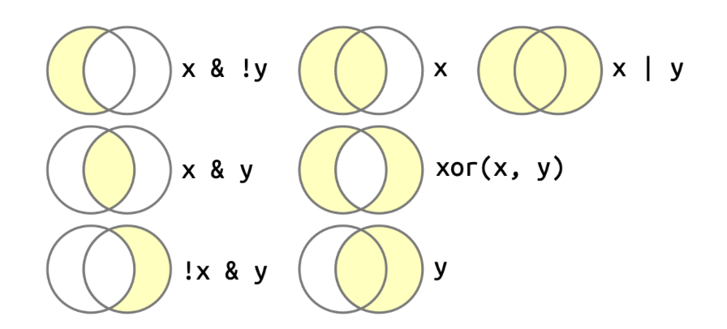

## Combining Logical Vectors

```r
x <- c(1, 2, 3, 4, 5)
(x > 3) & (x < 5)  # AND operator
```

```
[1] FALSE FALSE FALSE  TRUE FALSE
```

```r
(x > 3) | (x < 2)  # OR operator
```

```
[1]  TRUE FALSE FALSE  TRUE  TRUE
```

```r
!(x > 3)          # NOT operator
```

```
[1]  TRUE  TRUE  TRUE FALSE FALSE
```

```r
xor((x > 3), (x < 5)) # Exclusive or
```

```
[1]  TRUE  TRUE  TRUE FALSE  TRUE
```

`&`: Element-wise AND

`|`: Element-wise OR

`!`: Negation

## `%in%` Operator

Checks whether an element is found in other set.

```r
x <- c("apple", "banana", "cherry")
x %in% c("apple", "grape")
```

```
[1]  TRUE FALSE FALSE
```

## Short-circuit operators

`&&` and `||` are **short-circuit** operators

- Only evaluate on **scalars** and scalar output
- Useful in programming (e.g., control flow)
- Don’t use in `dplyr` functions!

```r
TRUE && FALSE  # FALSE (evaluates only the first element)
c(TRUE, FALSE) && c(FALSE, TRUE)  # error
```

## Floating point comparison

Checking equivalence with `==` with numeric (real numbers) is discouraged:

```r
x <- c(1 / 49 * 49, sqrt(2) ^ 2)
print(x)
```

```
[1] 1 2
```

When checking with `==`:

```r
x == c(1, 2)
```

```
[1] FALSE FALSE
```

**Why?**

- There’s no way to exactly represent `1/49` or `sqrt(2)` with fixed numbers whith decimal places
- Computers store **“close enough”** numbers for real numbers

```r
print(x, digits = 16)
```

```
[1] 0.9999999999999999 2.0000000000000004
```

That’s why `==` was failing.

To compare real numbers, use `dplyr::near()` function.

```r
near(x, c(1,2)) # near() from dplyr package (included in tidyverse)
```

```
[1] TRUE TRUE
```

## Logical Summaries

There are two logical summaries: `any()` and `all()`

`any(x)` is equivalent of `|`

- `TRUE` if any of `x` is `TRUE` including `NA`

`all(x)` is equivalent of `&`

- `TRUE` if all of `x` are `TRUE`
- `FALSE` if any of `x` is `FALSE` including `NA`

Check below:

```r
x <- c(TRUE, FALSE, TRUE)
any(x)
all(x)

y <- c(FALSE, FALSE, FALSE)
any(y)
all(y)
```

## Exercise

1. Write a line of code to create a logical vector from the numbers 1 to 10 that tests whether each number is greater than 5.
- Hint: Use the comparison operator `>` on the vector `1:10`.
2. Using the modulo operator, write code to extract the even numbers from the vector 1:20.
- Hint: A number is even if it leaves a remainder of 0 when divided by 2 (i.e., use `%%`)
3. Explain the result of TRUE & NA. What does this tell you about logical operations involving NA?
4. Suppose you have a vector of company tickers:

```r
tickers <- c("AAPL", "MSFT", "GOOG", "AMZN")
```

and portfolio:

```r
portfolio <- c("AAPL", "TSLA", "GOOG")
```

Write code to determine which tickers in `tickers` are present in `portfolio`. Yield a logical vector.

5. Suppose you have a vector of daily returns for a stock,

```r
daily_returns <- c(0.01, NA, -0.005, 0.02, NA)
```

1. Use any() to check if there is at least one positive return.
2. Use all() to check if all daily returns are positive.
3. Explain the outputs considering the presence of NA values.
- Check documentation `?any()` and `?all()`

# Numeric Vectors

## Numeric Vectors

Numeric vectors are the backbone of financial data. Numerics include:

- Integer
- Double (real, or float)

We will use tidyverse verbs—to manipulate numeric data in real-world finance examples.

## Parse numbers

Sometimes numbers are stored as **strings** (characters), especially when data was imported from external sources.

- **parse_double()** converts strings that are purely numeric
- **parse_number()** extracts numeric parts from strings

**parse_double()** example:

```r
# library(tidyverse)
price_str <- c("123.45", "67.89", "1e3")
typeof(price_str) # character

parsed_price <- parse_double(price_str)
print(parsed_price)
typeof(price_str)
```

**parse_number()** example:

```r
# Bond yields recorded with currency symbols
yield_str <- c("5.25 percent", "Yield 4.75", "It is 6.00%")
parsed_yields <- parse_number(yield_str)
print(parsed_yields)
```

## pmin, pmax

These functions compare values element-wise (rowwise in tibble).

```r
bond_yields1 <- c(3.5, 3.6, 3.7)
bond_yields2 <- c(3.8, 3.4, 3.9)
yields <- tibble(bond_yields1, bond_yields2)
yields |>
  mutate(
    min_yield = pmin(bond_yields1, bond_yields2),
    max_yield = pmax(bond_yields1, bond_yields2))
```

## Modular Arithmetic

Modular arithmetic is useful for breaking down composite numbers.

- `%/%` integer division (quotient)
- `%%` modulo operator (remainder)

For example, convert a time value in HHMM format to hours and minutes:

```r
# Suppose bond market closes at 1559 (3:59 PM)
close_time <- 1559
hour <- close_time %/% 100 # quotient
minute <- close_time %% 100 # remainder
```

## Logarithms

In Finance, logarithmic returns are often used. In R, `log()` is natural log. `log2()` and `log10()` have base of 2 and 10.

**Logarithmic (Log) Returns**

Calculated as the natural logarithm of the ratio of consecutive prices:

$r_{log} = \ln\left(\frac{P_t}{P_{t-1}}\right)$

Log returns are additive over time, which makes cumulative calculations more straightforward.

Key Differences between arithmetic and logarithmic returns:

**Additivity**

Log returns can be summed get the cumulative return, arithmetic returns must be compounded

**Approximation**

For small returns, log returns are very similar to arithmetic returns, but the difference becomes significant for larger returns

**Returns comparison**

Let’s see how to compute cumulative returns using both methods.

```r
prices <- c(100, 102, 101, 105, 107)
results <- tibble(
  Day = 1:length(prices),
  Price = prices
)
results <- results |>
  mutate(
    arith_ret = Price / lag(Price) - 1,
    log_ret = log(Price / lag(Price)),
    log_ret_convert = exp(log_ret) - 1,
    ) |>
  drop_na()
print(results)
```

**Cumulative Returns**

```r
results <- results |> mutate(
    cumprod_ari_ret = cumprod(1 + arith_ret) - 1,
    cumsum_log_ret = cumsum(log_ret),
    cumsum_log_ret_convert = exp(cumsum_log_ret) -1
  )
print(results)
```

## Rounding

Rounding is key for reporting. Use round(), floor(), and ceiling().

```r
price <- 123.456
floor(price)         # 123
floor(price * 100) / 100 # round down to the 2nd decimal
ceiling(price)       # 124
round(price, 2)      # 123.46 (nearest number)
round(price, -1)     # 120 (to the nearest ten)
```

## Cuts

`cut()` bins numeric values into discrete intervals with custom breaks.

```r
div_yields <- c(0.02, 0.03, 0.05, 0.07, 0.1)
yield_bins <- cut(div_yields, breaks = c(0, 0.03, 0.06, 0.1))
yield_bins <- cut(div_yields, breaks = c(0, 0.03, 0.06, 0.1), labels = c("Low", "Medium", "High"))
```

## Offsets

`dplyr::lead()` and `dplyr::lag()` allow you refer to values just before or after.

```r
prices <- c(150, 155, 160, 158)
lag(prices) # previous
lag(prices,2) # 2 times previous
lead(prices) # after
```

## Positions

Extract positions: `first()`, `last()`, `nth()`

```r
prices <- c(150, 155, 160, 158)
first(prices)
last(prices)
nth(prices,3)
```

## Exercise

For the price:

```r
price <- 987.654
```

Round price to

1. The nearest whole number
2. Two decimal places
3. Nearest ten

Parse below character vector of prices properly:

```r
price_str <- c("120.50", "99.99", "1e2")
price_str2 <- c("The price is $152", "aiming $199 dollars per stock", "reached $358 dollars")
```

# Date/Time Vectors

## Dates and Time in Finance

In finance, tracking dates and times is critical for modeling transactions, trade dates, settlement dates, and market events.

Although dates and times seem straightforward, they involve complexities such as:

- leap years
- time zones
- daylight saving time

## Create date and time

There are three types:

- A date, tibble prints as `<date>`
- A datetime, tibble prints as `<dttm>` also referred “POSIXct”
- A time, tibble prints as `<time>` from `hms`

R doesn’t have a native class for time, but `tidyverse (hms)` offers it.

## Simple Date and Time Vectors

`today()` and `now()` creates `date` and `datetime` class vectors.

```r
library(tidyverse)

# Current date and time
current_date <- today()
current_datetime <- now()
class(current_date)
class(current_datetime)
```

## Parse Date when Import

If external data has standard (i.e, ISO8601) date and datetime, `read_csv()` will automatically parse it.

```r
csv <- "
  date, datetime
  2022-01-02,2022-01-02 05:12
"
read_csv(csv)
```

## Parse Date with Manual Formatters

If external data has an ambiguous format, you can manually specify the format to handle.

```r
# Which is day, month, year?
csv <- "
  date
  01/02/15
"
read_csv(csv, col_types = cols(date = col_date("%m/%d/%y")))
read_csv(csv, col_types = cols(date = col_date("%d/%m/%y")))
read_csv(csv, col_types = cols(date = col_date("%y/%m/%d")))
```

## Date/Time formatters

| Type | Code | Meaning | Example |
| --- | --- | --- | --- |
| Year | `%Y` | 4 digit year | 2021 |
|  | `%y` | 2 digit year | 21 |
| Month | `%m` | Number | 2 |
|  | `%b` | Abbreviated name | Feb |
|  | `%B` | Full name | February |
| Day | `%d` | One or two digits | 2 |
| Time | `%H` | 24-hour hour | 13 |
|  | `%M` | Minutes | 35 |
|  | `%S` | Seconds | 45 |
|  | `%I` | 12-hour hour | 1 |
|  | `%p` | AM/PM | pm |
|  | `%Z` | Time zone name | America/Chicago |

## Exercise: Guess the Format!

Guess the correct Date/Time Format:

1. “2021-07-25”
2. “Jan, 1, 2011”
3. “07/25/21”
4. “2021-07-25 14:35:45”
5. “07/25/2021 02:35 PM”
6. “2021-07-25 14:35:45 EST”
7. “25 July 2021”

## Parse Strings to Date

Some cases are not handled perfectly by datetime format such as:

- “May 1st, 2023”
- “May 23rd, 2023”

`lubridate` package has nice handlers for those cases.

```r
date_str1 <- "Dec 25th, 2017"
date_str2 <- "2020-05-18"
date_str3 <- "5 October, 2023"
date_str4 <- "09/25/1986"
date_str5 <- "1988-9-4"

mdy(date_str1)
ymd(date_str2)
dmy(date_str3)
mdy(date_str4)
ymd(date_str5)
```

## Parse Strings to Datetime

`lubridate` package has nice handlers for datetime as well. Timezone must be specified correctly.

```r
trade_datetime_24 <- "2023-05-15 09:30:00"
trade_datetime_12 <- "May 15, 2023 09:30 AM"
trade_datetime_24_tz <- "2023-05-15 09:30:00 EST"

ymd_hms(trade_datetime_24) # UTC by default
ymd_hms(trade_datetime_24, tz = "EST") # set time zone at EST
mdy_hm(trade_datetime_12)
ymd_hms(trade_datetime_24_tz) # time zone should be mentioned
```

## Time zones

Time zones is not just a formatting. It changes underlying values especially when datetime is parsed from strings.

```r
trade_datetime_24 <- "2023-05-15 09:30:00"
utc <- ymd_hms(trade_datetime_24, tz = "UTC")
est <- ymd_hms(trade_datetime_24, tz = "EST")

unclass(utc) # 1684143000
unclass(est) # 1684161000
```

## Robust Time Zones

If you’re American you’ll know “EST” for Eastern Standard Time, but both Austrailia and Canada also have EST!

R uses international standard, IANA time zones, `{area}/{location}`.

```r
# To browse all time zone names, OlsonNames.
OlsonNames()
```

## Changing Time Zones

There are two scenarios that you want to change time zones:

1. Keep the instance but change time formatting
- Like converting time using world clock
2. Keep the time formatting but change instance
- Usually to fix the data error

## Keep the instance but formatting

`with_tz()` will keep the instance but change the time zone.

- As you would see from world clock!

```r
datetime <- ymd_hms("2023-01-01 12:00:00", tz = "America/New_York")
print(datetime)

with_tz(datetime, tzone = "America/Los_Angeles")
```

## Exercise

For following timezone, change time zone to *Chicago* keeping the instance.

```r
market_close <- ymd_hms("2023-01-01 16:00:00", tz = "America/New_York")
```

## Keep the formatting but instance

`force_tz()` will keep the time formatting but change the instance.

- To fix the data error

```r
market_close <- ymd_hms("2023-01-01 16:00:00", tz = "America/Chicago")
print(market_close)

force_tz(market_close, tzone = "America/New_York")
```

## Exercise

For following timezone, change time zone to *Chicago* keeping the instance.

```r
market_close <- ymd_hms("2023-01-01 15:00:00", tz = "America/New_York")
```

## Date/Time Components

You can pull out individual parts of the date with the accessor functions.

```r
datetime <- ymd_hms("2026-07-08 12:34:56")
class(datetime) # POSIXct

year(datetime)
month(datetime)
day(datetime)
mday(datetime) # same as day()
yday(datetime)
wday(datetime)
wday(datetime, label = TRUE)
hour(datetime)
minute(datetime)
second(datetime)
```

## Exercise

```r
example_datetime <- now()
```

What is the

- weekday
- month day
- yearday
- month
- second

of `example_datetime`?

## Rounding Dates

In Finance, flooring date / time is often used to matche frequency and most relevant information at a specific time.

`floor_date()`, `ceiling_date()` and `round_date()`

```r
last_traded_time <- ymd_hms("2024-09-08 13:33:45.653 EST", tz = "EST") # milliseconds
floor_date(last_traded_time) # by default, second
ceiling_date(last_traded_time)
floor_date(last_traded_time, unit = "10 seconds")
floor_date(last_traded_time, unit = "15 mins")
floor_date(last_traded_time, unit = "2 hours")
```

## Exercise

1. Convert the string into datetime object. Use Time zone: `America/New_York`

```r
last_traded_time <- "2024-09-08 13:33:45.653 EST"
```

2. Round down above trading time by “1 day”, “10 hours”, “5 minutes”, “10 seconds”

# Missing Values

## Missing Values

Missing values frequently appear in fianancial datasets.

Two types of missingness:

- **Explicit** missing: values marked `NA`
  - Presence of absence
- **Implicit** missing: absent rows that should be
  - Absense of presence

## Example

```r
financial_reports <- tibble(
  company = c("AAPL", "AAPL", "AAPL", "AAPL", "TSLA", "TSLA"),
  year = c(2020, 2020, 2020, 2021, 2021, 2021),
  quarter = c(1, 2, 3, 1, 1, 2),
  revenue = c(100, NA, 110, 200, 210, 220)
)
financial_reports |>
  gt::gt()
```

| company | year | quarter | revenue |
| --- | --- | --- | --- |
| AAPL | 2020 | 1 | 100 |
| AAPL | 2020 | 2 | NA |
| AAPL | 2020 | 3 | 110 |
| AAPL | 2021 | 1 | 200 |
| TSLA | 2021 | 1 | 210 |
| TSLA | 2021 | 2 | 220 |

- Explicit misssing:
  - `NA` values on the revenue
- Implicit missing:
  - AAPL: Q4 missing year 2020, …
  - TSLA: year 2020, and Q3, Q4 missing year 2021,

## Implicit Missing Values

Generally, you want to reveal those implicit missing cases as explicit. `tidyr::complete()` is handy for this operation.

**Note**

`tidyr` is included in `tidyverse`.

```r
# Provide set of variables of which combination should exist
financial_reports |>
  complete(company, year, quarter)
```

```
# A tibble: 12 × 4
   company  year quarter revenue
   <chr>   <dbl>   <dbl>   <dbl>
 1 AAPL     2020       1     100
 2 AAPL     2020       2      NA
 3 AAPL     2020       3     110
 4 AAPL     2021       1     200
 5 AAPL     2021       2      NA
 6 AAPL     2021       3      NA
 7 TSLA     2020       1      NA
 8 TSLA     2020       2      NA
 9 TSLA     2020       3      NA
10 TSLA     2021       1     210
11 TSLA     2021       2     220
12 TSLA     2021       3      NA
```

Since Q4 was missing for all, `complete()` fails to make every missing values explicit.

In this case, you can provide your own data.

## Explicit Missing Values

There are roughly 3 methods to handle missing values in Finance:

1. Filling with designated value
- e.g., Replace `NA` to 0
2. Last observation carried forward
- e.g., Use most recent past observation to fill `NA`
- c.f., Next observation carried backward
3. Linear Interpolation
- e.g., fill `NA` with incremental values in between

## Filling with designated value

Heuristic approach where you simply know (or assume) `NA` values. `ifelse()` is useful technique.

```r
financial_reports_ex |>
    mutate(revenue_filled = ifelse(is.na(revenue), 100, revenue))
```

```
# A tibble: 16 × 5
   company  year quarter revenue revenue_filled
   <chr>   <dbl>   <dbl>   <dbl>          <dbl>
 1 AAPL     2020       1     100            100
 2 AAPL     2020       2      NA            100
 3 AAPL     2020       3     110            110
 4 AAPL     2020       4      NA            100
 5 AAPL     2021       1     200            200
 6 AAPL     2021       2      NA            100
 7 AAPL     2021       3      NA            100
 8 AAPL     2021       4      NA            100
 9 TSLA     2020       1      NA            100
10 TSLA     2020       2      NA            100
11 TSLA     2020       3      NA            100
12 TSLA     2020       4      NA            100
13 TSLA     2021       1     210            210
14 TSLA     2021       2     220            220
15 TSLA     2021       3      NA            100
16 TSLA     2021       4      NA            100
```

Or you can use `tidyr::replace_na()` function.

```r
financial_reports_ex |>
    replace_na(list(revenue = 100))
```

```
# A tibble: 16 × 4
   company  year quarter revenue
   <chr>   <dbl>   <dbl>   <dbl>
 1 AAPL     2020       1     100
 2 AAPL     2020       2     100
 3 AAPL     2020       3     110
 4 AAPL     2020       4     100
 5 AAPL     2021       1     200
 6 AAPL     2021       2     100
 7 AAPL     2021       3     100
 8 AAPL     2021       4     100
 9 TSLA     2020       1     100
10 TSLA     2020       2     100
11 TSLA     2020       3     100
12 TSLA     2020       4     100
13 TSLA     2021       1     210
14 TSLA     2021       2     220
15 TSLA     2021       3     100
16 TSLA     2021       4     100
```

## Last observation carried forward

`tidyr::fill()` offers convenient filling options. It works like `select()` function.

```
- "down": fill downwards (LOCF)
- "up": fill upwards (NOCB)
- "downup": LOCF then NOCB
- "updown": NOCB then LOCF
```

When filling in direction, grouping and arranging is important.

```r
# Wrong case: using Apple's revenue to fill Tesla
financial_reports_ex |>
    fill(revenue, .direction = "down")
```

If you use LOCF, below is the correct approach:

```r
financial_reports_ex |>
    arrange(company, year, quarter) |>
    group_by(company) |>
    fill(revenue, .direction = "down")
```